# Final Group Project - Data Cleaning & Preparation

### Luke Therieau - Jason Michaud - Nathan Angell - Robert Mitchell

## Libaries Utilized:

```python
#!pip install --upgrade pandas
import pandas as pd
import warnings
%pylab inline
warnings.filterwarnings('ignore')
```

## Functions Used:

### Data_Dictionary_Transformation()

```python
def Data_Dictionary_Transformation(dict_source,First_Cols_Keep,First_Rows_Elim,Feature_Column,df):

    #Load Data Dictionary
    Data_Dictionary = pd.read_excel(dict_source,engine='openpyxl',usecols=list(range(First_Cols_Keep)))[:First_Rows_Elim]

    #Replace Spaces with Dashes
    Data_Dictionary[Feature_Column] = Data_Dictionary[Feature_Column].apply(lambda x: x.replace(' ','_'))

    #Features that are not in the data source
    Bad_Features = [feature for feature in Data_Dictionary[Feature_Column].values.tolist() if feature not in df.columns]

    #Features that are in the data source
    Good_Features = [feature for feature in df.columns if feature not in Data_Dictionary[Feature_Column].values.tolist() + ['Sort','Auto','Home']]

    Bad_To_Good_Dict = {Bad_Feat : Good_Feat for Bad_Feat,Good_Feat in zip(Bad_Features,Good_Features)}

    Data_Dictionary[Feature_Column] = Data_Dictionary[Feature_Column].apply(lambda x: Bad_To_Good_Dict[x] if x in Bad_Features else x)

    Data_Dictionary = Data_Dictionary.append(pd.DataFrame([[col]+['No Information']*4 for col in [col for col in df.columns.values.tolist() if col not in Data_Dictionary[Feature_Column].values.tolist()]],columns=Data_Dictionary.columns)).reset_index(drop=True).fillna('No Information')

    return Data_Dictionary
```

### Join()

```python
def Join(TableOne,TableTwo,TableOneJoinKey,TableTwoJoinKey):

    #Set TableTwo's index by TableTwoJoinKey
    TableTwo = TableTwo.set_index(TableTwoJoinKey)

    #Join Operation
    for col in [col for col in TableTwo.columns if col not in [TableTwoJoinKey]]:
        TableOne[col.title()] = TableOne[TableOneJoinKey].apply(lambda x: TableTwo.loc[x][col])

    #Return final results where TableOne and Table Two are joined similiar to a SQL JOIN
    return TableOne
```

### FeatureDashboard()

```python
def FeatureDashboard(df,Data_Dictionary,DISPLAY,SORT,Sort_Feature,ASC):

    #Dashboard Columns

    #Missing Obs. within each feature
    nullValues = pd.Series(df.isnull().sum())

    #Missing Obs. Percentage within each feature
    nullPercentage = pd.Series(round(df.isnull().sum()/df.shape[0],4))

    #Unique items within each feature
    uniqueObs = pd.DataFrame([[feature,len(df[feature].unique())] for feature in df.columns]).set_index(0)[1]
    featureDataTypes = pd.Series(df.dtypes,name='Data Type')

    #Create Dashboard
    dashboard = pd.concat([nullValues,nullPercentage,uniqueObs,featureDataTypes],axis=1).reset_index()

    #Dashboard Columns
    dashboard.columns = ['index','Missing','Null Percentage','Unique','Data Type']

    #Join Current Dashboard with information from the data dictionary to help further analysis
    dashboard = Join(TableOne = dashboard,TableTwo = Data_Dictionary,TableOneJoinKey = 'index',TableTwoJoinKey = 'FIELD NAME').rename({"index" : "Feature"},axis=1)

    #Flag for sorting dashboard based on a specific metric
    if SORT == True:
        dashboard = dashboard.sort_values(Sort_Feature,ascending = ASC).reset_index(drop=True)

    #Flag for displaying and returning the dashboard
    if DISPLAY == True:
        pd.set_option('display.max_rows', None)
        pd.set_option('display.max_colwidth', None)
        display(dashboard)
        pd.set_option('display.max_colwidth', 50)
        pd.set_option('display.max_rows', 10)
        return dashboard

    #Return final dashboard
    return dashboard
```

### Missing_Features()

```python
def Missing_Features(df,missing_threshold=0,drop=False):

    #Number of missing features per each observation
    df['Features_Missing'] = df.T.isnull().sum()

    #Filter data based off missing feature threshold where the observations above/equal will be filtered and displayed
    df2 = df[df['Features_Missing']>=((df.shape[1]-1)*missing_threshold)]
    display(df2)
    print(f"{df2.shape[0]}/{df.shape[0]} = {(df2.shape[0]/df.shape[0])*100}% of Observations")

    #Flag for droping the observations above/equal the threshold and keeping any observations bellow
    if drop == True:
        df = df[df['Features_Missing']<((df.shape[1]-1)*missing_threshold)].reset_index(drop=True).drop('Features_Missing',axis=1)
        return df
```

### Unique_Dashboard()

```python
def Unique_Dashboard(df,DISPLAY):

    #Data container for final results
    UniqueDashboard = []

    #All feature that are categorical in nature
    features = df.dtypes[(df.dtypes==object)|(df.dtypes==bool)].index.tolist()

    #For each feature we will find the unique item & proportion of the specific feature
    for feature in features:

        #Feature count used to get unique item and count of that item
        ValueCount = df[feature].value_counts()

        #Add result to data container
        UniqueDashboard.append([feature] + [[index,round(count/df.shape[0],4)] for index,count in zip(ValueCount.index,ValueCount.tolist())])

    #Convert data container into a dataframe
    UniqueDashboard = pd.DataFrame(UniqueDashboard).fillna('-').set_index(0)

    #flag for displaying the dashboard and not returning it
    if DISPLAY == True:
        pd.set_option('display.max_rows', None)
        pd.set_option('display.max_colwidth', None)
        pd.set_option('display.max_columns', None)
        display(UniqueDashboard)
        pd.set_option('display.max_colwidth', 50)
        pd.set_option('display.max_rows', 10)
        pd.set_option('display.max_columns', 20)

    #Or the dashboard will be returned for future use
    else:
        return UniqueDashboard
```

### findCorrelation()

```python
def findCorrelation(newData,excludedFeature):

    #Data which has a specific feature excluded
    newData = newData.drop(excludedFeature,axis=1)

    #Data container for final results
    corrList = []

    #For every Column in corr matrix
    for col in newData.corr().columns:

        #For every Row in corr matrix
        for row in range(newData.corr().shape[0]):

            #Add results to data container
            corrList.append([col,newData.corr().index[row],newData.corr().iloc[row][col]])

    #Convert datacontainer into a dataframe
    corrDF = pd.DataFrame(corrList,columns=['Feature_One','Feature_Two','Correlation']).sort_values('Correlation',ascending=False).reset_index(drop=True)

    #Filter corrDf to avoid any correlations of 1 (Same feature comparision)
    corrDF = corrDF[corrDF.Correlation != 1].reset_index(drop=True)

    #Return Results
    return corrDF
```

### GeoPandaGraph()

```python
def GeoPandaGraph(shp_file_name,df,df_column,shp_column):
    import geopandas

    #Load Shape File
    shp_file = geopandas.read_file(shp_file_name)

    #Counts for location based on metric
    ValueCounts = df[df_column].value_counts()/df.shape[0]

    #Exclude any locations that are not in data
    exclude = [town for town in shp_file[shp_column] if town not in Luke_Data[df_column].unique()]

    #Create column for counts created above
    shp_file['Frequency'] = shp_file[shp_column].apply(lambda x:
                                                       ValueCounts[str(x)]
                                                       if (x != None) & (x not in exclude)
                                                       else 0)

    #Create color map for value counts
    from matplotlib.colors import LinearSegmentedColormap
    cmap = LinearSegmentedColormap.from_list(
        'mycmap', [(0, '#2F2E2C'), (1, '#0025FF')])

    #Chlorpleth Map for specific area
    ax = shp_file.plot(column='Frequency',figsize=(7, 7), alpha=1, edgecolor='black',cmap=cmap, legend=True)

    #Set background to black for style reasons
    ax.set_facecolor('black')
    show()
```

### Sentence()

```python
def Sentence(x):

    #Remove punc from sentence
    for item in ['?','!',',','.','(',')','/','"']:
        x = str(x).replace(item,"")

    #Make sentence lower case and split by whitespace
    x = x.lower().split(" ")

    #If the sentence has one word make it null
    if len(x) == 1:
        x = nan

    #Set sentnece = 1 if item contains keywords
    else:
        if len([item for item in x if item in ['remove','drop','delete']]):
            x = 1

        #If keywords not present then make sentence null
        else:
            x = nan

    #Return x - p.s. making certain rows null will make them eaiser to drop so we can focus on keyword obs.
    return x
```

# 1. Load Data & First EDA:

```python
#AAA Data
AAAData = pd.read_table('../Project_Data/EDA_Project_Data/AAAData.txt',sep='|')
#AAA Data Dictionary
AAA_Dictionary = Data_Dictionary_Transformation(dict_source='../Project_Data/EDA_Project_Data/Bryant Spring 2021 - Data Dictionary v1.xlsx',
                                                First_Cols_Keep=5,
                                                First_Rows_Elim=-2,
                                                Feature_Column='FIELD NAME',
                                                df=AAAData)
```

## a. Feature Dashboard:

```python
AAAFeatureDashboard = FeatureDashboard(AAAData,
                                       AAA_Dictionary,
                                       DISPLAY = True,
                                       SORT = True,
                                       Sort_Feature='Null Percentage',
                                       ASC = False)
```

|  | Feature | Missing | Null Percentage | Unique | Data Type | Table | Source | Definition | Notes |
| --- | --- | --- | --- | --- | --- | --- | --- | --- | --- |
| 0 | Shell_Register_Date | 215514 | 0.9925 | 744 | object | Individual | AAA | Date member signed up for AAA / Shell partner discount. | No Information |
| 1 | Travel_Profit_Value_Y1 | 215452 | 0.9922 | 326 | float64 | Individual | AAA | No Information | No Information |
| 2 | Travel_Profit_Value_Y2 | 214153 | 0.9863 | 715 | float64 | Individual | AAA | No Information | No Information |
| 3 | Travel_Profit_Value_Y3 | 214037 | 0.9857 | 727 | float64 | Individual | AAA | No Information | No Information |
| 4 | Sprint_Status_Flag | 212976 | 0.9808 | 3 | object | No Information | No Information | No Information | No Information |
| 5 | Previous_State | 206912 | 0.9529 | 48 | object | Individual | 3rd party | State individual moved from. | Based on 3rd party sources, including USPS. |
| 6 | Reinstate_Date | 200163 | 0.9218 | 1334 | object | Members | AAA | Date of member's reinstatement to new membership | No Information |
| 7 | INS_Profit_Value_Y1 | 165900 | 0.7640 | 25345 | float64 | Individual | AAA | Sum of profit AAA has earned in the past 12 months. | No Information |
| 8 | Reason_Joined | 163920 | 0.7549 | 38 | object | Members | AAA | Reason for member joining AAA. | No Information |
| 9 | Months_from_Join_to_Cancel | 161382 | 0.7432 | 7 | object | Members | AAA | No Information | No Information |
| 10 | Cancel_Date | 161380 | 0.7432 | 2673 | object | Members | AAA | No Information | No Information |
| 11 | Cancel_Reason | 161380 | 0.7432 | 27 | object | Members | AAA | Reason for membership cancellation. | No Information |
| 12 | INS_Profit_Value_Y2 | 158502 | 0.7300 | 28294 | float64 | Individual | AAA | Sum of profit AAA has earned in 13 to 24 months previously. | No Information |
| 13 | INS_Profit_Value_Y3 | 158502 | 0.7300 | 28294 | float64 | Individual | AAA | Sum of profit AAA has earned in 25 to 36 months previously. | No Information |
| 14 | Gender | 143334 | 0.6601 | 4 | object | Members | AAA | NULL or Unknown, member did not respond | No Information |
| 15 | Min_Earliest_Insurance_Tx | 133867 | 0.6165 | 9825 | object | Individual | AAA | No Information | No Information |
| 16 | Count_Clicks_or_Opens | 133526 | 0.6149 | 101 | float64 | Individual | AAA | Total number of clocks or opens over the membership | No Information |
| 17 | Emails_Received | 133526 | 0.6149 | 276 | float64 | Individual | AAA | Total emails received over life of membership. | No Information |
| 18 | Email_Pref_Discounts_and_Rewards | 123230 | 0.5675 | 3 | object | Individual | AAA | AAA Member chooses to receive email. | Null = subscribe |
| 19 | Email_Pref_Student_Lending | 121895 | 0.5614 | 3 | object | Individual | AAA | AAA Member chooses to receive email. | Null = subscribe |
| 20 | Email_Pref_Memership_News | 121871 | 0.5613 | 3 | object | Individual | AAA | AAA Member chooses to receive email. | Null = subscribe |
| 21 | Email_Pref_Travel | 121287 | 0.5586 | 3 | object | Individual | AAA | AAA Member chooses to receive email. | Null = subscribe |
| 22 | Email_Pref_Auto_News_and_Offers | 121273 | 0.5585 | 3 | object | Individual | AAA | AAA Member chooses to receive email. | Null = subscribe |
| 23 | Email_Pref_Club_Deal_Travels | 121243 | 0.5584 | 3 | object | Individual | AAA | AAA Member chooses to receive email. | Null = subscribe |
| 24 | Email_Pref_Insurance | 121185 | 0.5581 | 3 | object | Individual | AAA | AAA Member chooses to receive email. | Null = subscribe |
| 25 | Email_Pref_Financial_Services | 121120 | 0.5578 | 3 | object | Individual | AAA | AAA Member chooses to receive email. | Null = subscribe |
| 26 | Education_Model | 109082 | 0.5024 | 11 | object | Individual | 3rd party | No Information | Grouping based on 3rd party . |
| 27 | Business_Owner | 109082 | 0.5024 | 3 | object | Individual | 3rd party | Does individual own a business. | Grouping based on 3rd party . |
| 28 | Occupation_Group | 109082 | 0.5024 | 19 | object | Individual | 3rd party | No Information | Grouping based on 3rd party . |
| 29 | Credit_RangesDecode | 106280 | 0.4895 | 9 | object | Individual | 3rd party | Credit score range. | Grouping based on 3rd party . |

[output cut: 77 more lines]

## b. Observations That Have More Than 50% of Features Missing:

This was used to see if certain number of observations had more than a select number of features missing. Look at "Features_Missing" to see number of missing features per obs

```python
Missing_Features(AAAData,missing_threshold=0.50,drop=False)
```

|  | Age | Auto_In_The_Market_New | Auto_In_The_Market_Used | Business_Owner | Children | Children_Presence_Of_Child_0to18 | City | Consumerview_Profitability_Score | Count_Clicks_or_Opens | County | ... | Membership_ID | Months_from_Join_to_Cancel | Reason_Joined | Reinstate_Date | Renew_Method | Sprint_Status_Flag | Policy_Holder_Flag_2 | Auto | Home | Features_Missing |
| --- | --- | --- | --- | --- | --- | --- | --- | --- | --- | --- | --- | --- | --- | --- | --- | --- | --- | --- | --- | --- | --- |
| 286 | NaN | NaN | NaN | NaN | NaN | NaN | BROCKTON | NaN | NaN | NaN | ... | 18911 | NaN | U | NaN | AUTO RENEW | NaN | NaN | 0 | 0 | 73 |
| 773 | NaN | NaN | NaN | NaN | NaN | NaN | CHERRY VALLEY | NaN | NaN | NaN | ... | 39804 | NaN | NaN | NaN | AUTO RENEW | NaN | NaN | 0 | 0 | 73 |
| 7935 | NaN | NaN | NaN | NaN | NaN | NaN | ACTON | NaN | NaN | NaN | ... | 343558 | NaN | NaN | NaN | NOTICE | NaN | NaN | 0 | 0 | 74 |
| 22917 | NaN | NaN | NaN | NaN | NaN | NaN | NORTH ATTLEBORO | NaN | NaN | NaN | ... | 1008493 | NaN | NaN | NaN | AUTO RENEW | NaN | NaN | 0 | 0 | 74 |
| 23929 | NaN | NaN | NaN | NaN | NaN | NaN | WALTHAM | NaN | NaN | NaN | ... | 1043761 | NaN | NaN | NaN | AUTO RENEW | NaN | NaN | 0 | 0 | 73 |
| ... | ... | ... | ... | ... | ... | ... | ... | ... | ... | ... | ... | ... | ... | ... | ... | ... | ... | ... | ... | ... | ... |
| 190678 | NaN | NaN | NaN | NaN | NaN | NaN | WATERTOWN | NaN | NaN | NaN | ... | 8414752 | NaN | NaN | NaN | AUTO RENEW | NaN | NaN | 0 | 0 | 74 |
| 198172 | NaN | NaN | NaN | NaN | NaN | NaN | WORCESTER | NaN | NaN | NaN | ... | 8752253 | NaN | NaN | NaN | AUTO RENEW | NaN | NaN | 1 | 1 | 74 |
| 199914 | NaN | NaN | NaN | NaN | NaN | NaN | CHARLESTOWN | NaN | NaN | NaN | ... | 8811768 | NaN | U | NaN | AUTO RENEW | NaN | NaN | 0 | 0 | 73 |
| 207817 | NaN | NaN | NaN | NaN | NaN | NaN | REHOBOTH | NaN | NaN | NaN | ... | 9293873 | NaN | Insur | 7/9/2020 12:00:00 AM | NOTICE | NaN | NaN | 0 | 0 | 71 |
| 211782 | NaN | NaN | NaN | NaN | NaN | NaN | EAST WAREHAM | NaN | NaN | NaN | ... | 9621105 | NaN | U | NaN | AUTO RENEW | NaN | NaN | 0 | 0 | 72 |

68 rows × 108 columns

```
68/217136 = 0.03131677842458183% of Observations
```

## c. Number of Columns Based Off Missing Observations Cutoff:

```python
cutoff = 0.7
AAAData[AAAFeatureDashboard[AAAFeatureDashboard['Null Percentage']<=cutoff]['Feature'].values.tolist()].columns.shape[0]
```

```
93
```

## d. Removed All Features That Were Above Cutoff of 70%

```python
cutoff = 0.7
NewAAAData = AAAData[AAAFeatureDashboard[AAAFeatureDashboard['Null Percentage']<=cutoff]['Feature'].values.tolist()]

NewAAAFeatureDashboard = FeatureDashboard(NewAAAData,
                                          AAA_Dictionary,
                                          DISPLAY = False,
                                          SORT = True,
                                          Sort_Feature='Null Percentage',
                                          ASC = False)
```

# 2. Luke's Features:

## a. Filter Dataset for Luke's Features:

```python
Luke_Features = ["Age",
"Count_Clicks_or_Opens",
"Auto_In_The_Market_New",
"Auto_In_The_Market_Used",
"Business_Owner",
"Children",
"Children_Presence_Of_Child_0to18",
"City",
"Consumerview_Profitability_Score",
"County",
"Credit_RangesDecode",
"Donor_Flag",
"DRV_Driving_School_Flag",
"Dwelling_Type",
"Education",
"Education_Model",
"Email_Pref_Auto_News_and_Offers",
"Email_Pref_Club_Deal_Travels",
"Email_Pref_Discounts_and_Rewards",
"Email_Pref_Financial_Services",
"Email_Pref_Insurance",
"Email_Pref_Memership_News",
"Email_Pref_Student_Lending",
"Email_Pref_Travel"]

Luke_Data = NewAAAData[Luke_Features]
```

## b. Luke's Feature Dashboard:

```python
LukeDashboard = FeatureDashboard(Luke_Data,
                                       AAA_Dictionary,
                                       DISPLAY = True,
                                       SORT = True,
                                       Sort_Feature='Null Percentage',
                                       ASC = False)
```

|  | Feature | Missing | Null Percentage | Unique | Data Type | Table | Source | Definition | Notes |
| --- | --- | --- | --- | --- | --- | --- | --- | --- | --- |
| 0 | Count_Clicks_or_Opens | 133526 | 0.6149 | 101 | float64 | Individual | AAA | Total number of clocks or opens over the membership | No Information |
| 1 | Email_Pref_Discounts_and_Rewards | 123230 | 0.5675 | 3 | object | Individual | AAA | AAA Member chooses to receive email. | Null = subscribe |
| 2 | Email_Pref_Student_Lending | 121895 | 0.5614 | 3 | object | Individual | AAA | AAA Member chooses to receive email. | Null = subscribe |
| 3 | Email_Pref_Memership_News | 121871 | 0.5613 | 3 | object | Individual | AAA | AAA Member chooses to receive email. | Null = subscribe |
| 4 | Email_Pref_Travel | 121287 | 0.5586 | 3 | object | Individual | AAA | AAA Member chooses to receive email. | Null = subscribe |
| 5 | Email_Pref_Auto_News_and_Offers | 121273 | 0.5585 | 3 | object | Individual | AAA | AAA Member chooses to receive email. | Null = subscribe |
| 6 | Email_Pref_Club_Deal_Travels | 121243 | 0.5584 | 3 | object | Individual | AAA | AAA Member chooses to receive email. | Null = subscribe |
| 7 | Email_Pref_Insurance | 121185 | 0.5581 | 3 | object | Individual | AAA | AAA Member chooses to receive email. | Null = subscribe |
| 8 | Email_Pref_Financial_Services | 121120 | 0.5578 | 3 | object | Individual | AAA | AAA Member chooses to receive email. | Null = subscribe |
| 9 | Business_Owner | 109082 | 0.5024 | 3 | object | Individual | 3rd party | Does individual own a business. | Grouping based on 3rd party . |
| 10 | Education_Model | 109082 | 0.5024 | 11 | object | Individual | 3rd party | No Information | Grouping based on 3rd party . |
| 11 | Credit_RangesDecode | 106280 | 0.4895 | 9 | object | Individual | 3rd party | Credit score range. | Grouping based on 3rd party . |
| 12 | Education | 90727 | 0.4178 | 6 | object | Individual | 3rd party | No Information | Grouping based on 3rd party . |
| 13 | Age | 90727 | 0.4178 | 78 | float64 | Individual | 3rd party | No Information | Multiple like fields may exist. |
| 14 | Dwelling_Type | 90728 | 0.4178 | 4 | object | Individual | 3rd party | 3rd party classification of home / dwelling. | No Information |
| 15 | Children | 90727 | 0.4178 | 3 | object | Individual | 3rd party | Is there a presence of under 18 year old in the household. | Indicator of probability. |
| 16 | Auto_In_The_Market_New | 64269 | 0.2960 | 10 | object | Individual | 3rd party | indicates individual may have a 'new' vehicle. | Indicator of probability. |
| 17 | Auto_In_The_Market_Used | 63023 | 0.2902 | 10 | object | Individual | 3rd party | indicates individual may have a 'new' vehicle. | Indicator of probability. |
| 18 | Consumerview_Profitability_Score | 58385 | 0.2689 | 6 | object | Individual | 3rd party | No Information | Indicator of probability. |
| 19 | Children_Presence_Of_Child_0to18 | 58385 | 0.2689 | 5 | object | Individual | 3rd party | No Information | Indicator of probability. |
| 20 | Donor_Flag | 61 | 0.0003 | 3 | object | Individual | AAA | Payer of another membership (gift). | No Information |
| 21 | County | 65 | 0.0003 | 553 | object | Individual | AAA or 3rd party | Address of individual. | No Information |
| 22 | DRV_Driving_School_Flag | 61 | 0.0003 | 3 | object | Individual | AAA | Child of member participated in AAA driving school. | No Information |
| 23 | City | 0 | 0.0000 | 2172 | object | Individual | AAA | Address of individual. | No Information |

## c. Based on Feature Dashboard, Replace Missing Obs with "subscribe" for select features:

```python
NullSubscribe = LukeDashboard[LukeDashboard['Notes']=='Null = subscribe']['Feature'].values.tolist()
for feature in NullSubscribe:
    Luke_Data[feature] = Luke_Data[feature].fillna('Subscribe')
```

## d. Unique Items and their percentage within each Feature:

```python
Unique_Dashboard(Luke_Data,DISPLAY=True)
```

| 0 | 1 | 2 | 3 | 4 | 5 | 6 | 7 | 8 | 9 | 10 | 11 | 12 | 13 | 14 | 15 | 16 | 17 | 18 | 19 | 20 | 21 | 22 | 23 | 24 | 25 | 26 | 27 | 28 | 29 | … |
| --- | --- | --- | --- | --- | --- | --- | --- | --- | --- | --- | --- | --- | --- | --- | --- | --- | --- | --- | --- | --- | --- | --- | --- | --- | --- | --- | --- | --- | --- | --- |
| Auto_In_The_Market_New | [Extremely Likely, 0.1338] | [Highly Likely, 0.1243] | [Very Likely, 0.1027] | [Somewhat Likely, 0.0882] | [Likely, 0.0734] | [Somewhat Unlikely, 0.0606] | [Very Unlikely, 0.0504] | [Highly Unlikely, 0.0401] | [Extremely Unlikely, 0.0305] | - | - | - | - | - | - | - | - | - | - | - | - | - | - | - | - | - | - | - | - | … |
| Auto_In_The_Market_Used | [Extremely Unlikely, 0.102] | [Very Unlikely, 0.0995] | [Highly Unlikely, 0.0993] | [Somewhat Unlikely, 0.0913] | [Likely, 0.0845] | [Somewhat Likely, 0.0755] | [Very Likely, 0.0632] | [Highly Likely, 0.0552] | [Extremely Likely, 0.0392] | - | - | - | - | - | - | - | - | - | - | - | - | - | - | - | - | - | - | - | - | … |
| Business_Owner | [Unknown, 0.4808] | [Yes, 0.0168] | - | - | - | - | - | - | - | - | - | - | - | - | - | - | - | - | - | - | - | - | - | - | - | - | - | - | - | … |
| Children | [Yes, 0.3501] | [No, 0.232] | - | - | - | - | - | - | - | - | - | - | - | - | - | - | - | - | - | - | - | - | - | - | - | - | - | - | - | … |
| Children_Presence_Of_Child_0to18 | [Not likely to have a child, 0.3292] | [Modeled not as likely to have a child, 0.1663] | [Known data, 0.1492] | [Modeled likely to have a child, 0.0864] | - | - | - | - | - | - | - | - | - | - | - | - | - | - | - | - | - | - | - | - | - | - | - | - | - | … |
| City | [WORCESTER, 0.0261] | [BOSTON, 0.0186] | [NEW BEDFORD, 0.0163] | [FALL RIVER, 0.0153] | [LOWELL, 0.0135] | [CAMBRIDGE, 0.0133] | [PLYMOUTH, 0.0124] | [QUINCY, 0.0121] | [FRAMINGHAM, 0.0119] | [HAVERHILL, 0.0118] | [ATTLEBORO, 0.0118] | [BROCKTON, 0.0106] | [WALTHAM, 0.0097] | [LYNN, 0.0095] | [TAUNTON, 0.0091] | [SOMERVILLE, 0.0089] | [PEABODY, 0.0081] | [LEOMINSTER, 0.0081] | [ARLINGTON, 0.008] | [MARLBOROUGH, 0.0079] | [PITTSFIELD, 0.0078] | [DORCHESTER, 0.0076] | [METHUEN, 0.0074] | [BROOKLINE, 0.0074] | [LAWRENCE, 0.0073] | [BEVERLY, 0.0069] | [MEDFORD, 0.0069] | [SALEM, 0.0067] | [NATICK, 0.0066] | … |
| Consumerview_Profitability_Score | [High Profitability, High Likelihood to Perform, 0.3664] | [Good Profitability, Medium Likelihood to Perform, 0.1579] | [Fair Profitability, Medium Likelihood to Perform, 0.1502] | [Poor Profitability, Unlikely to Perform, 0.0566] | [Low Profitability, Unlikely to Perform, 0.0] | - | - | - | - | - | - | - | - | - | - | - | - | - | - | - | - | - | - | - | - | - | - | - | - | … |
| County | [MIDDLESEX, 0.2429] | [WORCESTER, 0.1423] | [ESSEX, 0.1208] | [NORFOLK, 0.1133] | [BRISTOL, 0.1102] | [PLYMOUTH, 0.0875] | [SUFFOLK, 0.0754] | [BARNSTABLE, 0.0526] | [BERKSHIRE, 0.0213] | [DUKES, 0.0035] | [PROVIDENCE, 0.0027] | [NANTUCKET, 0.0022] | [HAMPDEN, 0.0021] | [HAMPSHIRE, 0.0019] | [HILLSBOROUGH, 0.0013] | [ROCKINGHAM, 0.0013] | [FRANKLIN, 0.0011] | [LOS ANGELES, 0.0005] | [NEWPORT, 0.0005] | [KENT, 0.0005] | [WINDHAM, 0.0005] | [WASHINGTON, 0.0004] | [ORANGE, 0.0004] | [SAN DIEGO, 0.0003] | [CUMBERLAND, 0.0003] | [HARTFORD, 0.0003] | [NEW HAVEN, 0.0003] | [YORK, 0.0003] | [SANTA CLARA, 0.0003] | … |
| Credit_RangesDecode | [750 to 799, 0.1806] | [700 to 749, 0.1193] | [650 to 699, 0.0782] | [800 and up, 0.0677] | [600 to 649, 0.04] | [550 to 599, 0.0161] | [500 to 549, 0.0076] | [499 and Le, 0.001] | - | - | - | - | - | - | - | - | - | - | - | - | - | - | - | - | - | - | - | - | - | … |
| Donor_Flag | [False, 0.9537] | [True, 0.046] | - | - | - | - | - | - | - | - | - | - | - | - | - | - | - | - | - | - | - | - | - | - | - | - | - | - | - | … |
| DRV_Driving_School_Flag | [N, 0.9936] | [Y, 0.0062] | - | - | - | - | - | - | - | - | - | - | - | - | - | - | - | - | - | - | - | - | - | - | - | - | - | - | - | … |
| Dwelling_Type | [Single Family, 0.4402] | [Multi Family Dwelling/Apartment, 0.1172] | [PO Box, 0.0247] | - | - | - | - | - | - | - | - | - | - | - | - | - | - | - | - | - | - | - | - | - | - | - | - | - | - | … |
| Education | [Some College, 0.196] | [Unknown, 0.1739] | [High School, 0.135] | [Completed College, 0.0699] | [Graduated School, 0.0073] | - | - | - | - | - | - | - | - | - | - | - | - | - | - | - | - | - | - | - | - | - | - | - | - | … |
| Education_Model | [HS Diploma - Likely, 0.105] | [Some College - Likely, 0.0719] | [Bach Degree - Likely, 0.0679] | [Grad Degree - Likely, 0.0678] | [Bach Degree - Extremely Likely, 0.0649] | [Some College -Extremely Likely, 0.0333] | [Grad Degree - Extremely Likely, 0.0317] | [Less than HS Diploma - Likely, 0.0288] | [HS Diploma - Extremely Likely, 0.026] | [Less than HS Diploma - Ex Like, 0.0003] | - | - | - | - | - | - | - | - | - | - | - | - | - | - | - | - | - | - | - | … |
| Email_Pref_Auto_News_and_Offers | [Subscribe, 0.6888] | [Unsubscribe, 0.3112] | - | - | - | - | - | - | - | - | - | - | - | - | - | - | - | - | - | - | - | - | - | - | - | - | - | - | - | … |
| Email_Pref_Club_Deal_Travels | [Subscribe, 0.6887] | [Unsubscribe, 0.3113] | - | - | - | - | - | - | - | - | - | - | - | - | - | - | - | - | - | - | - | - | - | - | - | - | - | - | - | … |
| Email_Pref_Discounts_and_Rewards | [Subscribe, 0.6993] | [Unsubscribe, 0.3007] | - | - | - | - | - | - | - | - | - | - | - | - | - | - | - | - | - | - | - | - | - | - | - | - | - | - | - | … |
| Email_Pref_Financial_Services | [Subscribe, 0.688] | [Unsubscribe, 0.312] | - | - | - | - | - | - | - | - | - | - | - | - | - | - | - | - | - | - | - | - | - | - | - | - | - | - | - | … |
| Email_Pref_Insurance | [Subscribe, 0.6884] | [Unsubscribe, 0.3116] | - | - | - | - | - | - | - | - | - | - | - | - | - | - | - | - | - | - | - | - | - | - | - | - | - | - | - | … |
| Email_Pref_Memership_News | [Subscribe, 0.692] | [Unsubscribe, 0.308] | - | - | - | - | - | - | - | - | - | - | - | - | - | - | - | - | - | - | - | - | - | - | - | - | - | - | - | … |
| Email_Pref_Student_Lending | [Subscribe, 0.6921] | [Unsubscribe, 0.3079] | - | - | - | - | - | - | - | - | - | - | - | - | - | - | - | - | - | - | - | - | - | - | - | - | - | - | - | … |
| Email_Pref_Travel | [Subscribe, 0.689] | [Unsubscribe, 0.311] | - | - | - | - | - | - | - | - | - | - | - | - | - | - | - | - | - | - | - | - | - | - | - | - | - | - | - | … |

Many features were either flags, true/false, or specfic text like names or categories.

## e. Replace all missing categorical features with "Missing Observation":

```python
features = Luke_Data.dtypes[(Luke_Data.dtypes==object)|(Luke_Data.dtypes==bool)].index.tolist()
for feature in features:
    Luke_Data[feature] = Luke_Data[feature].fillna('Missing Observation')
```

## f. Replace Non Mass. counites with "Not Mass" & County EDA:

```python
Luke_Data['County'] = Luke_Data['County'].apply(lambda x: x if str(x).title() in ['Barnstable',
                                                                                  'Berkshire',
                                                                                  'Bristol',
                                                                                  'Dukes',
                                                                                  'Essex',
                                                                                  'Franklin',
                                                                                  'Hampden',
                                                                                  'Hampshire',
                                                                                  'Middlesex',
                                                                                  'Nantucket',
                                                                                  'Norfolk',
                                                                                  'Plymouth',
                                                                                  'Suffolk',
                                                                                  'Worcester'] else 'Not Mass')
```

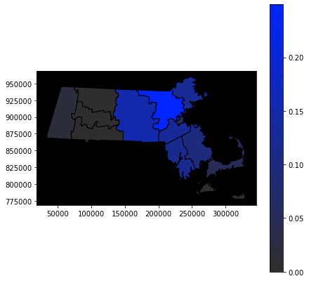

```python
GeoPandaGraph(shp_file_name = '../Project_Data/EDA_Project_Data/Shape_Data/counties',
              df = Luke_Data.replace('Not Mass',nan).dropna(),
              df_column = 'County',
              shp_column = 'COUNTY')
```

Middlesex county had alot of observations i.e. 20%

## g. Handle Numerical Feature Missing Observations:

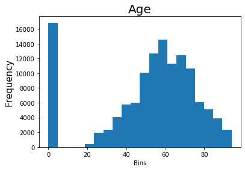

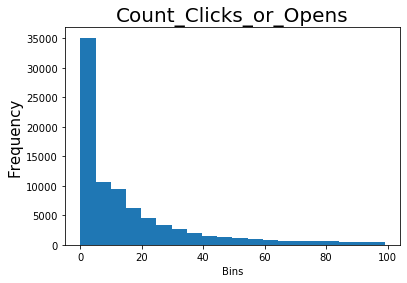

```python
features = Luke_Data.dtypes[(Luke_Data.dtypes==int)|(Luke_Data.dtypes==float)].index.tolist()
for feature in features:
    hist(Luke_Data[feature],bins=20)
    title(feature,size=20)
    ylabel('Frequency',size=15)
    xlabel('Bins')
    show()
```

```python
Luke_Data['Age'] = Luke_Data['Age'].apply(lambda x: nan if x == 0.0 else x)
Luke_Data['Age'] = Luke_Data['Age'].fillna(Luke_Data['Age'].median())
mode = int(Luke_Data['Count_Clicks_or_Opens'].mode())
Luke_Data['Count_Clicks_or_Opens'] = Luke_Data['Count_Clicks_or_Opens'].fillna(mode)
```

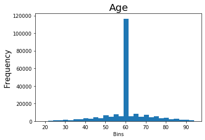

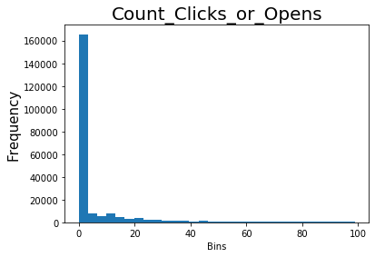

```python
for feature in features:
    hist(Luke_Data[feature],bins=30)
    title(feature,size=20)
    ylabel('Frequency',size=15)
    xlabel('Bins')
    show()
```

## h. Handle Multicollinearity with Email_Pref features:

```python
df = Luke_Data[NullSubscribe]
df = df.replace({"Subscribe" : 1,"Unsubscribe" : 0})
display(findCorrelation(df,[]))
new_Feature = pd.Series(df.T.sum().apply(lambda x: 'Unsubscribe' if x < 1 else "Subscribe"),name='Email_Prefrence_For_At_least_One_Product')
df = Luke_Data[[feature for feature in Luke_Data.columns if feature not in NullSubscribe]]
Luke_Data = pd.concat([df,new_Feature],axis=1)
```

|  | Feature_One | Feature_Two | Correlation |
| --- | --- | --- | --- |
| 0 | Email_Pref_Insurance | Email_Pref_Financial_Services | 0.997693 |
| 1 | Email_Pref_Financial_Services | Email_Pref_Insurance | 0.997693 |
| 2 | Email_Pref_Travel | Email_Pref_Club_Deal_Travels | 0.997207 |
| 3 | Email_Pref_Club_Deal_Travels | Email_Pref_Travel | 0.997207 |
| 4 | Email_Pref_Auto_News_and_Offers | Email_Pref_Financial_Services | 0.996556 |
| ... | ... | ... | ... |
| 51 | Email_Pref_Discounts_and_Rewards | Email_Pref_Insurance | 0.972300 |
| 52 | Email_Pref_Financial_Services | Email_Pref_Discounts_and_Rewards | 0.972127 |
| 53 | Email_Pref_Discounts_and_Rewards | Email_Pref_Financial_Services | 0.972127 |
| 54 | Email_Pref_Memership_News | Email_Pref_Student_Lending | 0.968687 |
| 55 | Email_Pref_Student_Lending | Email_Pref_Memership_News | 0.968687 |

56 rows × 3 columns

## i. City Feature EDA & Drop Select Features:

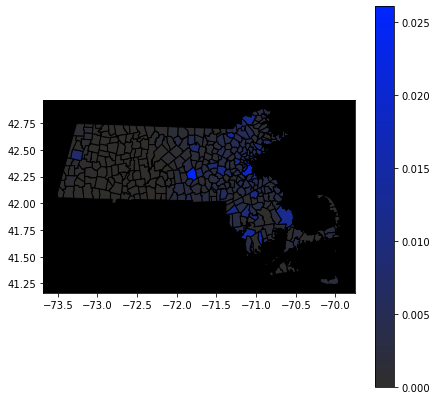

```python
Luke_Data['City'] = Luke_Data['City'].apply(lambda x: x.upper())
GeoPandaGraph(shp_file_name = '../Project_Data/EDA_Project_Data/Shape_Data/towns',
              df = Luke_Data.dropna(),
              df_column = 'City',
              shp_column = 'TOWN')
```

- Age: Replaced with Jason’s Age Feature
- Business_Owner: Does individual own a business (3rd Party) - 1.68% Yes
- Children_Presence_Of_Child_0to18: Probability of children in household (3rd Party)
- City: City member leaves in (AAA) - 2172 Unique Observations
- Donor_Flag: Payer of another membership (gift) (AAA) - 95% False
- DRV_Driving_School_Flag: Child of member participated in AAA driving school - 99.36% No
- Education_Model: Probability of having specific education level (3rd Party)

```python
Luke_Data = Luke_Data.drop(['Business_Owner',
                            'Children_Presence_Of_Child_0to18',
                            'City',
                            'Donor_Flag',
                            'DRV_Driving_School_Flag',
                            'Education_Model',
                            'Age'],axis=1)
```

```python
print(f"Missing Observations: {Luke_Data.isnull().sum().sum()}")
```

```
Missing Observations: 0
```

# 3. Bobby's Features:

```python
Bobby_Features = ['Email_Pref_Your_AAA_Digital',
                  'Emails_Received',
                  'Est_Household_IncomeDecode',
                  'Estimated_Income_Code',
                  'FSV_CMSI_Flag',
                  'FSV_Credit_Card_Flag',
                  'FSV_Deposit_Program_Flag',
                  'FSV_ID_Theft_Flag',
                  'FSV_Mortgage_Count',
                  'FSV_Mortgage_Flag',
                  'FSV_TCI_Count',
                  'FSV_TCI_Flag',
                  'FSV_TrueCar_Leads_Count',
                  'FSV_TrueCar_Sales_Count',
                  'Gender_Code',
                  'Hertz_Gold_Ind',
                  'Household_Key',
                  'Individual_Key',
                  'INS_Homeowners_Policy_Flag',
                  'INS_Other_Policy_Flag',
                  'INS_Personal_Auto_Policy_Flag',
                  'INS_Policies_Count',
                  'INS_Policies_Flag']

Bobby_Data = NewAAAData[Bobby_Features]
```

```python
BobbyDashboard = FeatureDashboard(Bobby_Data,
                   AAA_Dictionary,
                   DISPLAY = True,
                   SORT = True,
                   Sort_Feature='Null Percentage',
                   ASC = False)
```

|  | Feature | Missing | Null Percentage | Unique | Data Type | Table | Source | Definition | Notes |
| --- | --- | --- | --- | --- | --- | --- | --- | --- | --- |
| 0 | Emails_Received | 133526 | 0.6149 | 276 | float64 | Individual | AAA | Total emails received over life of membership. | No Information |
| 1 | Estimated_Income_Code | 105237 | 0.4847 | 20 | object | Individual | 3rd party | No Information | Grouping based on 3rd party . |
| 2 | Email_Pref_Your_AAA_Digital | 88725 | 0.4086 | 3 | object | Individual | AAA | AAA Member chooses to receive email. | Null = subscribe |
| 3 | Est_Household_IncomeDecode | 58385 | 0.2689 | 7 | object | Individual | 3rd party | Based on sum of all individuals in a HH. | Indicator of probability. |
| 4 | INS_Policies_Count | 61 | 0.0003 | 76 | float64 | Individual | AAA | The number of transactions that exist related to that members policies. | Each annual renewal has it's own transaction record. |
| 5 | INS_Personal_Auto_Policy_Flag | 61 | 0.0003 | 3 | object | Individual | AAA | Has (has had) one or more Auto policies with AAA. | Regardless of Active / Inactive status. |
| 6 | INS_Other_Policy_Flag | 61 | 0.0003 | 3 | object | Individual | AAA | Has (has had) one or more Insurance policies other than Auto or Home with AAA. | Regardless of Active / Inactive status. |
| 7 | INS_Homeowners_Policy_Flag | 61 | 0.0003 | 3 | object | Individual | AAA | Has (has had) one or more Home Owner's Insurance policies with AAA. | Regardless of Active / Inactive status. |
| 8 | Gender_Code | 61 | 0.0003 | 5 | object | Individual | AAA or 3rd party | Gender as reported by a 3rd Party. | May differ from other sources. |
| 9 | FSV_TrueCar_Sales_Count | 61 | 0.0003 | 3 | float64 | Individual | AAA | Used AAA link to engage with TrueCar and purchased a vehicle. | No Information |
| 10 | FSV_TrueCar_Leads_Count | 61 | 0.0003 | 15 | float64 | Individual | AAA | Used AAA link to engage with TrueCar. | No Information |
| 11 | FSV_TCI_Flag | 61 | 0.0003 | 3 | object | Individual | AAA | Took out an Auto Loan at some point during membership | No Information |
| 12 | FSV_TCI_Count | 61 | 0.0003 | 7 | float64 | Individual | AAA | Flag indicating if individual has gotten an Auto Loan through AAA. Based on current auto loan bse. | No Information |
| 13 | FSV_Mortgage_Flag | 61 | 0.0003 | 3 | object | Individual | AAA | Took out a mortgage / refinance from AAA Northeast. | No Information |
| 14 | FSV_Mortgage_Count | 61 | 0.0003 | 9 | float64 | Individual | AAA | Flag indicating if individual has engaged (purchased, signed up for, inquired about) in last 5 years. | No Information |
| 15 | FSV_ID_Theft_Flag | 61 | 0.0003 | 3 | object | Individual | AAA | Signed up for AAA's free or paid Identity Theft monitoring service. | No Information |
| 16 | FSV_Deposit_Program_Flag | 61 | 0.0003 | 3 | object | Individual | AAA | Has (has had) a Savings account, CD, Money Market with AAA. | No Information |
| 17 | FSV_Credit_Card_Flag | 61 | 0.0003 | 3 | object | Individual | AAA | Signed up for and issued a AAA credit card. | No Information |
| 18 | FSV_CMSI_Flag | 61 | 0.0003 | 3 | object | Individual | AAA | Took out a mortgage / refinance from AAA Northeast. | No Information |
| 19 | INS_Policies_Flag | 61 | 0.0003 | 3 | object | Individual | AAA | Has (has had) one or more Insurance policies with AAA. | No Information |
| 20 | Hertz_Gold_Ind | 0 | 0.0000 | 2 | object | Individual | AAA | Signed up with Hertz Gold program through AAA. | No Information |
| 21 | Household_Key | 0 | 0.0000 | 201432 | int64 | Individual | System generated | Key used to link all individuals to the same HH. | No Information |
| 22 | Individual_Key | 0 | 0.0000 | 217136 | int64 | Individual | System generated | Key assigned to each individual. | Used |

```python
NullSubscribe = BobbyDashboard[BobbyDashboard['Notes']=='Null = subscribe']['Feature'].values.tolist()
for feature in NullSubscribe:
    Bobby_Data[feature] = Bobby_Data[feature].fillna('Subscribe')
```

```python
Unique_Dashboard(Bobby_Data,DISPLAY=True)
```

| 0 | 1 | 2 | 3 | 4 | 5 | 6 | 7 | 8 | 9 | 10 | 11 | 12 | 13 | 14 | 15 | 16 | 17 | 18 | 19 |
| --- | --- | --- | --- | --- | --- | --- | --- | --- | --- | --- | --- | --- | --- | --- | --- | --- | --- | --- | --- |
| Email_Pref_Your_AAA_Digital | [Unsubscribe, 0.519] | [Subscribe, 0.481] | - | - | - | - | - | - | - | - | - | - | - | - | - | - | - | - | - |
| Est_Household_IncomeDecode | [03 - $50K - $99.99K, 0.2134] | [04 - $100K-$149.99K, 0.1579] | [06 - $200,000 +, 0.1101] | [02 - $25K - $49.99K, 0.0964] | [05 - $150K - $199.99K, 0.0803] | [01 - less than $25,000, 0.073] | - | - | - | - | - | - | - | - | - | - | - | - | - |
| Estimated_Income_Code | [$100,000-$149,999, 0.1197] | [$75,000-$99,999, 0.0816] | [$250,000+, 0.0422] | [$200,000-$249,999, 0.0345] | [$175,000-$199,999, 0.0314] | [$65,000-$74,999, 0.0307] | [$150,000-$174,999, 0.0249] | [$60,000-$64,999, 0.0196] | [$10,000-$14,999, 0.0186] | [$45,000-$49,999, 0.0169] | [$55,000-$59,999, 0.0168] | [$35,000-$39,999, 0.0147] | [$25,000-$29,999, 0.0128] | [$50,000-$54,999, 0.0115] | [$15,000-$19,999, 0.0106] | [$40,000-$44,999, 0.0088] | [Under $10,000, 0.0074] | [$30,000-$34,999, 0.0069] | [$20,000-$24,999, 0.0058] |
| FSV_CMSI_Flag | [N, 0.9452] | [Y, 0.0545] | - | - | - | - | - | - | - | - | - | - | - | - | - | - | - | - | - |
| FSV_Credit_Card_Flag | [N, 0.9554] | [Y, 0.0443] | - | - | - | - | - | - | - | - | - | - | - | - | - | - | - | - | - |
| FSV_Deposit_Program_Flag | [N, 0.9974] | [Y, 0.0023] | - | - | - | - | - | - | - | - | - | - | - | - | - | - | - | - | - |
| FSV_ID_Theft_Flag | [N, 0.9698] | [Y, 0.0299] | - | - | - | - | - | - | - | - | - | - | - | - | - | - | - | - | - |
| FSV_Mortgage_Flag | [N, 0.9968] | [Y, 0.0029] | - | - | - | - | - | - | - | - | - | - | - | - | - | - | - | - | - |
| FSV_TCI_Flag | [N, 0.9895] | [Y, 0.0103] | - | - | - | - | - | - | - | - | - | - | - | - | - | - | - | - | - |
| Gender_Code | [F, 0.4662] | [M, 0.4518] | [U, 0.0546] | [X, 0.0271] | - | - | - | - | - | - | - | - | - | - | - | - | - | - | - |
| Hertz_Gold_Ind | [N, 0.9884] | [Y, 0.0116] | - | - | - | - | - | - | - | - | - | - | - | - | - | - | - | - | - |
| INS_Homeowners_Policy_Flag | [N, 0.7915] | [Y, 0.2082] | - | - | - | - | - | - | - | - | - | - | - | - | - | - | - | - | - |
| INS_Other_Policy_Flag | [N, 0.9392] | [Y, 0.0605] | - | - | - | - | - | - | - | - | - | - | - | - | - | - | - | - | - |
| INS_Personal_Auto_Policy_Flag | [N, 0.643] | [Y, 0.3567] | - | - | - | - | - | - | - | - | - | - | - | - | - | - | - | - | - |
| INS_Policies_Flag | [N, 0.6162] | [Y, 0.3835] | - | - | - | - | - | - | - | - | - | - | - | - | - | - | - | - | - |

```python
FeatureDashboard(Bobby_Data,
                   AAA_Dictionary,
                   DISPLAY = True,
                   SORT = True,
                   Sort_Feature='Null Percentage',
                   ASC = False)
```

|  | Feature | Missing | Null Percentage | Unique | Data Type | Table | Source | Definition | Notes |
| --- | --- | --- | --- | --- | --- | --- | --- | --- | --- |
| 0 | Emails_Received | 133526 | 0.6149 | 276 | float64 | Individual | AAA | Total emails received over life of membership. | No Information |
| 1 | Estimated_Income_Code | 105237 | 0.4847 | 20 | object | Individual | 3rd party | No Information | Grouping based on 3rd party . |
| 2 | Est_Household_IncomeDecode | 58385 | 0.2689 | 7 | object | Individual | 3rd party | Based on sum of all individuals in a HH. | Indicator of probability. |
| 3 | FSV_TCI_Flag | 61 | 0.0003 | 3 | object | Individual | AAA | Took out an Auto Loan at some point during membership | No Information |
| 4 | INS_Policies_Count | 61 | 0.0003 | 76 | float64 | Individual | AAA | The number of transactions that exist related to that members policies. | Each annual renewal has it's own transaction record. |
| 5 | INS_Personal_Auto_Policy_Flag | 61 | 0.0003 | 3 | object | Individual | AAA | Has (has had) one or more Auto policies with AAA. | Regardless of Active / Inactive status. |
| 6 | INS_Other_Policy_Flag | 61 | 0.0003 | 3 | object | Individual | AAA | Has (has had) one or more Insurance policies other than Auto or Home with AAA. | Regardless of Active / Inactive status. |
| 7 | INS_Homeowners_Policy_Flag | 61 | 0.0003 | 3 | object | Individual | AAA | Has (has had) one or more Home Owner's Insurance policies with AAA. | Regardless of Active / Inactive status. |
| 8 | Gender_Code | 61 | 0.0003 | 5 | object | Individual | AAA or 3rd party | Gender as reported by a 3rd Party. | May differ from other sources. |
| 9 | FSV_TrueCar_Sales_Count | 61 | 0.0003 | 3 | float64 | Individual | AAA | Used AAA link to engage with TrueCar and purchased a vehicle. | No Information |
| 10 | FSV_TrueCar_Leads_Count | 61 | 0.0003 | 15 | float64 | Individual | AAA | Used AAA link to engage with TrueCar. | No Information |
| 11 | INS_Policies_Flag | 61 | 0.0003 | 3 | object | Individual | AAA | Has (has had) one or more Insurance policies with AAA. | No Information |
| 12 | FSV_TCI_Count | 61 | 0.0003 | 7 | float64 | Individual | AAA | Flag indicating if individual has gotten an Auto Loan through AAA. Based on current auto loan bse. | No Information |
| 13 | FSV_Mortgage_Flag | 61 | 0.0003 | 3 | object | Individual | AAA | Took out a mortgage / refinance from AAA Northeast. | No Information |
| 14 | FSV_Mortgage_Count | 61 | 0.0003 | 9 | float64 | Individual | AAA | Flag indicating if individual has engaged (purchased, signed up for, inquired about) in last 5 years. | No Information |
| 15 | FSV_ID_Theft_Flag | 61 | 0.0003 | 3 | object | Individual | AAA | Signed up for AAA's free or paid Identity Theft monitoring service. | No Information |
| 16 | FSV_Deposit_Program_Flag | 61 | 0.0003 | 3 | object | Individual | AAA | Has (has had) a Savings account, CD, Money Market with AAA. | No Information |
| 17 | FSV_Credit_Card_Flag | 61 | 0.0003 | 3 | object | Individual | AAA | Signed up for and issued a AAA credit card. | No Information |
| 18 | FSV_CMSI_Flag | 61 | 0.0003 | 3 | object | Individual | AAA | Took out a mortgage / refinance from AAA Northeast. | No Information |
| 19 | Hertz_Gold_Ind | 0 | 0.0000 | 2 | object | Individual | AAA | Signed up with Hertz Gold program through AAA. | No Information |
| 20 | Household_Key | 0 | 0.0000 | 201432 | int64 | Individual | System generated | Key used to link all individuals to the same HH. | No Information |
| 21 | Individual_Key | 0 | 0.0000 | 217136 | int64 | Individual | System generated | Key assigned to each individual. | Used |
| 22 | Email_Pref_Your_AAA_Digital | 0 | 0.0000 | 2 | object | Individual | AAA | AAA Member chooses to receive email. | Null = subscribe |

|  | Feature | Missing | Null Percentage | Unique | Data Type | Table | Source | Definition | Notes |
| --- | --- | --- | --- | --- | --- | --- | --- | --- | --- |
| 0 | Emails_Received | 133526 | 0.6149 | 276 | float64 | Individual | AAA | Total emails received over life of membership. | No Information |
| 1 | Estimated_Income_Code | 105237 | 0.4847 | 20 | object | Individual | 3rd party | No Information | Grouping based on 3rd party . |
| 2 | Est_Household_IncomeDecode | 58385 | 0.2689 | 7 | object | Individual | 3rd party | Based on sum of all individuals in a HH. | Indicator of probability. |
| 3 | FSV_TCI_Flag | 61 | 0.0003 | 3 | object | Individual | AAA | Took out an Auto Loan at some point during mem... | No Information |
| 4 | INS_Policies_Count | 61 | 0.0003 | 76 | float64 | Individual | AAA | The number of transactions that exist related ... | Each annual renewal has it's own transaction r... |
| ... | ... | ... | ... | ... | ... | ... | ... | ... | ... |
| 18 | FSV_CMSI_Flag | 61 | 0.0003 | 3 | object | Individual | AAA | Took out a mortgage / refinance from AAA North... | No Information |
| 19 | Hertz_Gold_Ind | 0 | 0.0000 | 2 | object | Individual | AAA | Signed up with Hertz Gold program through AAA. | No Information |
| 20 | Household_Key | 0 | 0.0000 | 201432 | int64 | Individual | System generated | Key used to link all individuals to the same HH. | No Information |
| 21 | Individual_Key | 0 | 0.0000 | 217136 | int64 | Individual | System generated | Key assigned to each individual. | Used |
| 22 | Email_Pref_Your_AAA_Digital | 0 | 0.0000 | 2 | object | Individual | AAA | AAA Member chooses to receive email. | Null = subscribe |

23 rows × 9 columns

```python
#df = Bobby_Data[NullSubscribe]
#df = df.replace({"Subscribe" : 1,"Unsubscribe" : 0})
#display(findCorrelation(df,[]))
#new_Feature = pd.Series(df.T.sum().apply(lambda x: 'Unsubscribe' if x < 1 else "Subscribe"),name='Email_Prefrence_For_At_least_One_Product')
#df = Bobby_Data[[feature for feature in Bobby_Data.columns if feature not in NullSubscribe]]
#Bobby_Data = pd.concat([df,new_Feature],axis=1)
```

```python
df = Bobby_Data
features = df.dtypes[(df.dtypes==object)|(df.dtypes==bool)].index.tolist()
for feature in features:
    Bobby_Data[feature] = Bobby_Data[feature].fillna('Missing Observation')
```

```python
FeatureDashboard(Bobby_Data,
                   AAA_Dictionary,
                   DISPLAY = True,
                   SORT = True,
                   Sort_Feature='Null Percentage',
                   ASC = False)
```

|  | Feature | Missing | Null Percentage | Unique | Data Type | Table | Source | Definition | Notes |
| --- | --- | --- | --- | --- | --- | --- | --- | --- | --- |
| 0 | Emails_Received | 133526 | 0.6149 | 276 | float64 | Individual | AAA | Total emails received over life of membership. | No Information |
| 1 | INS_Policies_Count | 61 | 0.0003 | 76 | float64 | Individual | AAA | The number of transactions that exist related to that members policies. | Each annual renewal has it's own transaction record. |
| 2 | FSV_Mortgage_Count | 61 | 0.0003 | 9 | float64 | Individual | AAA | Flag indicating if individual has engaged (purchased, signed up for, inquired about) in last 5 years. | No Information |
| 3 | FSV_TCI_Count | 61 | 0.0003 | 7 | float64 | Individual | AAA | Flag indicating if individual has gotten an Auto Loan through AAA. Based on current auto loan bse. | No Information |
| 4 | FSV_TrueCar_Leads_Count | 61 | 0.0003 | 15 | float64 | Individual | AAA | Used AAA link to engage with TrueCar. | No Information |
| 5 | FSV_TrueCar_Sales_Count | 61 | 0.0003 | 3 | float64 | Individual | AAA | Used AAA link to engage with TrueCar and purchased a vehicle. | No Information |
| 6 | Email_Pref_Your_AAA_Digital | 0 | 0.0000 | 2 | object | Individual | AAA | AAA Member chooses to receive email. | Null = subscribe |
| 7 | Gender_Code | 0 | 0.0000 | 5 | object | Individual | AAA or 3rd party | Gender as reported by a 3rd Party. | May differ from other sources. |
| 8 | INS_Personal_Auto_Policy_Flag | 0 | 0.0000 | 3 | object | Individual | AAA | Has (has had) one or more Auto policies with AAA. | Regardless of Active / Inactive status. |
| 9 | INS_Other_Policy_Flag | 0 | 0.0000 | 3 | object | Individual | AAA | Has (has had) one or more Insurance policies other than Auto or Home with AAA. | Regardless of Active / Inactive status. |
| 10 | INS_Homeowners_Policy_Flag | 0 | 0.0000 | 3 | object | Individual | AAA | Has (has had) one or more Home Owner's Insurance policies with AAA. | Regardless of Active / Inactive status. |
| 11 | Individual_Key | 0 | 0.0000 | 217136 | int64 | Individual | System generated | Key assigned to each individual. | Used |
| 12 | Household_Key | 0 | 0.0000 | 201432 | int64 | Individual | System generated | Key used to link all individuals to the same HH. | No Information |
| 13 | Hertz_Gold_Ind | 0 | 0.0000 | 2 | object | Individual | AAA | Signed up with Hertz Gold program through AAA. | No Information |
| 14 | FSV_TCI_Flag | 0 | 0.0000 | 3 | object | Individual | AAA | Took out an Auto Loan at some point during membership | No Information |
| 15 | FSV_Mortgage_Flag | 0 | 0.0000 | 3 | object | Individual | AAA | Took out a mortgage / refinance from AAA Northeast. | No Information |
| 16 | FSV_ID_Theft_Flag | 0 | 0.0000 | 3 | object | Individual | AAA | Signed up for AAA's free or paid Identity Theft monitoring service. | No Information |
| 17 | FSV_Deposit_Program_Flag | 0 | 0.0000 | 3 | object | Individual | AAA | Has (has had) a Savings account, CD, Money Market with AAA. | No Information |
| 18 | FSV_Credit_Card_Flag | 0 | 0.0000 | 3 | object | Individual | AAA | Signed up for and issued a AAA credit card. | No Information |
| 19 | FSV_CMSI_Flag | 0 | 0.0000 | 3 | object | Individual | AAA | Took out a mortgage / refinance from AAA Northeast. | No Information |
| 20 | Estimated_Income_Code | 0 | 0.0000 | 20 | object | Individual | 3rd party | No Information | Grouping based on 3rd party . |
| 21 | Est_Household_IncomeDecode | 0 | 0.0000 | 7 | object | Individual | 3rd party | Based on sum of all individuals in a HH. | Indicator of probability. |
| 22 | INS_Policies_Flag | 0 | 0.0000 | 3 | object | Individual | AAA | Has (has had) one or more Insurance policies with AAA. | No Information |

|  | Feature | Missing | Null Percentage | Unique | Data Type | Table | Source | Definition | Notes |
| --- | --- | --- | --- | --- | --- | --- | --- | --- | --- |
| 0 | Emails_Received | 133526 | 0.6149 | 276 | float64 | Individual | AAA | Total emails received over life of membership. | No Information |
| 1 | INS_Policies_Count | 61 | 0.0003 | 76 | float64 | Individual | AAA | The number of transactions that exist related ... | Each annual renewal has it's own transaction r... |
| 2 | FSV_Mortgage_Count | 61 | 0.0003 | 9 | float64 | Individual | AAA | Flag indicating if individual has engaged (pur... | No Information |
| 3 | FSV_TCI_Count | 61 | 0.0003 | 7 | float64 | Individual | AAA | Flag indicating if individual has gotten an Au... | No Information |
| 4 | FSV_TrueCar_Leads_Count | 61 | 0.0003 | 15 | float64 | Individual | AAA | Used AAA link to engage with TrueCar. | No Information |
| ... | ... | ... | ... | ... | ... | ... | ... | ... | ... |
| 18 | FSV_Credit_Card_Flag | 0 | 0.0000 | 3 | object | Individual | AAA | Signed up for and issued a AAA credit card. | No Information |
| 19 | FSV_CMSI_Flag | 0 | 0.0000 | 3 | object | Individual | AAA | Took out a mortgage / refinance from AAA North... | No Information |
| 20 | Estimated_Income_Code | 0 | 0.0000 | 20 | object | Individual | 3rd party | No Information | Grouping based on 3rd party . |
| 21 | Est_Household_IncomeDecode | 0 | 0.0000 | 7 | object | Individual | 3rd party | Based on sum of all individuals in a HH. | Indicator of probability. |
| 22 | INS_Policies_Flag | 0 | 0.0000 | 3 | object | Individual | AAA | Has (has had) one or more Insurance policies w... | No Information |

23 rows × 9 columns

### 1. Email_Pref_Your_AAA_Digital

```python
df['Email_Pref_Your_AAA_Digital'].isnull().sum()
```

```
0
```

```python
df['Email_Pref_Your_AAA_Digital'].value_counts()
```

```
Unsubscribe    112704
Subscribe      104432
Name: Email_Pref_Your_AAA_Digital, dtype: int64
```

## Going to combine with new feature in Luke's features list

## 3. FSV_CMSI_Flag

```python
df['FSV_CMSI_Flag'].value_counts()
```

```
N                      205245
Y                       11830
Missing Observation        61
Name: FSV_CMSI_Flag, dtype: int64
```

## 4. FSV_Credit_Card_Flag

```python
df['FSV_Credit_Card_Flag'].isnull().sum()
```

```
0
```

```python
df['FSV_Credit_Card_Flag'].value_counts()
```

```
N                      207446
Y                        9629
Missing Observation        61
Name: FSV_Credit_Card_Flag, dtype: int64
```

## 5. FSV_Deposit_Program_Flag

```python
df['FSV_Deposit_Program_Flag'].isnull().sum()
```

```
0
```

```python
df['FSV_Deposit_Program_Flag'].value_counts()
```

```
N                      216579
Y                         496
Missing Observation        61
Name: FSV_Deposit_Program_Flag, dtype: int64
```

```python
df = df.drop(columns = 'FSV_Deposit_Program_Flag',axis=0)
```

```python
df.head()
```

|  | Email_Pref_Your_AAA_Digital | Emails_Received | Est_Household_IncomeDecode | Estimated_Income_Code | FSV_CMSI_Flag | FSV_Credit_Card_Flag | FSV_ID_Theft_Flag | FSV_Mortgage_Count | FSV_Mortgage_Flag | FSV_TCI_Count | ... | FSV_TrueCar_Sales_Count | Gender_Code | Hertz_Gold_Ind | Household_Key | Individual_Key | INS_Homeowners_Policy_Flag | INS_Other_Policy_Flag | INS_Personal_Auto_Policy_Flag | INS_Policies_Count | INS_Policies_Flag |
| --- | --- | --- | --- | --- | --- | --- | --- | --- | --- | --- | --- | --- | --- | --- | --- | --- | --- | --- | --- | --- | --- |
| 0 | Unsubscribe | NaN | 02 - $25K - $49.99K | $55,000-$59,999 | N | N | N | 0.0 | N | 0.0 | ... | 0.0 | F | N | 3522662 | 13736727 | Y | N | Y | 18.0 | Y |
| 1 | Unsubscribe | NaN | 06 - $200,000 + | $250,000+ | N | N | N | 0.0 | N | 0.0 | ... | 0.0 | F | N | 10762750 | 17069519 | N | N | N | 0.0 | N |
| 2 | Unsubscribe | NaN | 02 - $25K - $49.99K | $100,000-$149,999 | N | Y | Y | 0.0 | N | 0.0 | ... | 0.0 | M | N | 875 | 1366420 | Y | Y | Y | 59.0 | Y |
| 3 | Subscribe | NaN | 01 - less than $25,000 | Missing Observation | N | Y | N | 0.0 | N | 0.0 | ... | 0.0 | F | N | 6591739 | 21291510 | N | N | Y | 9.0 | Y |
| 4 | Unsubscribe | NaN | 06 - $200,000 + | Missing Observation | N | N | N | 0.0 | N | 0.0 | ... | 0.0 | M | N | 19610747 | 10318661 | N | N | N | 0.0 | N |

5 rows × 22 columns

## 6. Estimated_Income_Code

```python
df['Estimated_Income_Code'].isnull().sum()
```

```
0
```

```python
df = df.drop(columns = 'Estimated_Income_Code',axis=0)
```

Going to use Est_Household_IncomeDecode instead of Estimated_Income_Code

## 7. Emails_Received

```python
df['Emails_Received'].isnull().sum()
```

```
133526
```

## 8. FSV_ID_Theft_Flag

```python
df['FSV_ID_Theft_Flag'].isnull().sum()
```

```
0
```

```python
df['FSV_ID_Theft_Flag'].value_counts()
```

```
N                      210574
Y                        6501
Missing Observation        61
Name: FSV_ID_Theft_Flag, dtype: int64
```

## 9. FSV_Mortgage_Count

```python
df['FSV_Mortgage_Count'].value_counts()
```

```
0.0    216338
1.0       584
2.0       109
3.0        31
4.0        10
8.0         1
7.0         1
6.0         1
Name: FSV_Mortgage_Count, dtype: int64
```

## 10. FSV_Mortgage_Flag

```python
df['FSV_Mortgage_Flag'].value_counts()
```

```
N                      216446
Y                         629
Missing Observation        61
Name: FSV_Mortgage_Flag, dtype: int64
```

## 11. FSV_TCI_Count

```python
df['FSV_TCI_Count'].value_counts()
```

```
0.0    214847
1.0      1925
2.0       249
3.0        45
4.0         6
5.0         3
Name: FSV_TCI_Count, dtype: int64
```

Dropped because we already have a similar feature called FSV_TCI_Flag

## 12. FSV_TCI_Flag

```python
df['FSV_TCI_Flag'].value_counts()
```

```
N                      214847
Y                        2228
Missing Observation        61
Name: FSV_TCI_Flag, dtype: int64
```

## 13. FSV_TrueCar_Leads_Count

```python
df['FSV_TrueCar_Leads_Count'].isnull().sum()
df['FSV_TrueCar_Leads_Count'].value_counts()
```

```
0.0     216864
3.0         86
2.0         38
1.0         37
5.0         15
         ...
8.0          1
13.0         1
10.0         1
17.0         1
12.0         1
Name: FSV_TrueCar_Leads_Count, Length: 14, dtype: int64
```

Feature Dropped due to skewed distribution

## 14. FSV_TrueCar_Sales_Count

```python
df['FSV_TrueCar_Sales_Count'].value_counts()
```

```
0.0    217032
1.0        43
Name: FSV_TrueCar_Sales_Count, dtype: int64
```

## 15. Gender_Code

Variable already exists

```python
df['Gender_Code'].value_counts()
```

```
F                      101236
M                       98107
U                       11850
X                        5882
Missing Observation        61
Name: Gender_Code, dtype: int64
```

## 16. Hertz_Gold_Ind

```python
df['Hertz_Gold_Ind'].isnull().sum()
```

```
0
```

```python
df['Hertz_Gold_Ind'].value_counts()
```

```
N    214627
Y      2509
Name: Hertz_Gold_Ind, dtype: int64
```

## 17. INS_Homeowners_Policy_Flag

```python
df['INS_Homeowners_Policy_Flag'].value_counts()
```

```
N                      171864
Y                       45211
Missing Observation        61
Name: INS_Homeowners_Policy_Flag, dtype: int64
```

## 18. INS_Other_Policy_Flag

```python
df['INS_Other_Policy_Flag'].value_counts()
```

```
N                      203942
Y                       13133
Missing Observation        61
Name: INS_Other_Policy_Flag, dtype: int64
```

## 19. INS_Personal_Auto_Policy_Flag

```python
df['INS_Personal_Auto_Policy_Flag'].value_counts()
```

```
N                      139618
Y                       77457
Missing Observation        61
Name: INS_Personal_Auto_Policy_Flag, dtype: int64
```

```python
df['INS_Personal_Auto_Policy_Flag'].isnull().sum()
```

```
0
```

## 20. INS_Policies_Count

```python
df['INS_Policies_Count'].isnull().sum()
```

```
61
```

```python
df['INS_Policies_Count'].describe()
```

```
count    217075.000000
mean          3.871874
std           7.003679
min           0.000000
25%           0.000000
50%           0.000000
75%           6.000000
max          94.000000
Name: INS_Policies_Count, dtype: float64
```

```python
df['INS_Policies_Count'].value_counts()
```

```
0.0     133806
2.0       8150
11.0      7875
4.0       6314
1.0       5156
         ...
77.0         1
65.0         1
68.0         1
59.0         1
66.0         1
Name: INS_Policies_Count, Length: 75, dtype: int64
```

## 21. INS_Policies_Flag

```python
df['INS_Policies_Flag'].value_counts()
```

```
N                      133806
Y                       83269
Missing Observation        61
Name: INS_Policies_Flag, dtype: int64
```

## 22. Est_Household_IncomeDecode

```python
df['Est_Household_IncomeDecode'].value_counts()
```

```
Missing Observation       58385
03 - $50K - $99.99K       46344
04 - $100K-$149.99K       34289
06 - $200,000 +           23901
02 - $25K - $49.99K       20940
05 - $150K - $199.99K     17431
01 - less than $25,000    15846
Name: Est_Household_IncomeDecode, dtype: int64
```

```python
df['Est_Household_IncomeDecode'] = df['Est_Household_IncomeDecode'].str.extract(r'([0-9]{2})')
```

```python
df['Est_Household_IncomeDecode'].value_counts()
```

```
03    46344
04    34289
06    23901
02    20940
05    17431
01    15846
Name: Est_Household_IncomeDecode, dtype: int64
```

```python
FeatureDashboard(df,
                   AAA_Dictionary,
                   DISPLAY = True,
                   SORT = True,
                   Sort_Feature='Null Percentage',
                   ASC = False)
```

|  | Feature | Missing | Null Percentage | Unique | Data Type | Table | Source | Definition | Notes |
| --- | --- | --- | --- | --- | --- | --- | --- | --- | --- |
| 0 | Emails_Received | 133526 | 0.6149 | 276 | float64 | Individual | AAA | Total emails received over life of membership. | No Information |
| 1 | Est_Household_IncomeDecode | 58385 | 0.2689 | 7 | object | Individual | 3rd party | Based on sum of all individuals in a HH. | Indicator of probability. |
| 2 | FSV_TrueCar_Leads_Count | 61 | 0.0003 | 15 | float64 | Individual | AAA | Used AAA link to engage with TrueCar. | No Information |
| 3 | INS_Policies_Count | 61 | 0.0003 | 76 | float64 | Individual | AAA | The number of transactions that exist related to that members policies. | Each annual renewal has it's own transaction record. |
| 4 | FSV_Mortgage_Count | 61 | 0.0003 | 9 | float64 | Individual | AAA | Flag indicating if individual has engaged (purchased, signed up for, inquired about) in last 5 years. | No Information |
| 5 | FSV_TCI_Count | 61 | 0.0003 | 7 | float64 | Individual | AAA | Flag indicating if individual has gotten an Auto Loan through AAA. Based on current auto loan bse. | No Information |
| 6 | FSV_TrueCar_Sales_Count | 61 | 0.0003 | 3 | float64 | Individual | AAA | Used AAA link to engage with TrueCar and purchased a vehicle. | No Information |
| 7 | Hertz_Gold_Ind | 0 | 0.0000 | 2 | object | Individual | AAA | Signed up with Hertz Gold program through AAA. | No Information |
| 8 | INS_Personal_Auto_Policy_Flag | 0 | 0.0000 | 3 | object | Individual | AAA | Has (has had) one or more Auto policies with AAA. | Regardless of Active / Inactive status. |
| 9 | INS_Other_Policy_Flag | 0 | 0.0000 | 3 | object | Individual | AAA | Has (has had) one or more Insurance policies other than Auto or Home with AAA. | Regardless of Active / Inactive status. |
| 10 | INS_Homeowners_Policy_Flag | 0 | 0.0000 | 3 | object | Individual | AAA | Has (has had) one or more Home Owner's Insurance policies with AAA. | Regardless of Active / Inactive status. |
| 11 | Individual_Key | 0 | 0.0000 | 217136 | int64 | Individual | System generated | Key assigned to each individual. | Used |
| 12 | Household_Key | 0 | 0.0000 | 201432 | int64 | Individual | System generated | Key used to link all individuals to the same HH. | No Information |
| 13 | Email_Pref_Your_AAA_Digital | 0 | 0.0000 | 2 | object | Individual | AAA | AAA Member chooses to receive email. | Null = subscribe |
| 14 | Gender_Code | 0 | 0.0000 | 5 | object | Individual | AAA or 3rd party | Gender as reported by a 3rd Party. | May differ from other sources. |
| 15 | FSV_TCI_Flag | 0 | 0.0000 | 3 | object | Individual | AAA | Took out an Auto Loan at some point during membership | No Information |
| 16 | FSV_Mortgage_Flag | 0 | 0.0000 | 3 | object | Individual | AAA | Took out a mortgage / refinance from AAA Northeast. | No Information |
| 17 | FSV_ID_Theft_Flag | 0 | 0.0000 | 3 | object | Individual | AAA | Signed up for AAA's free or paid Identity Theft monitoring service. | No Information |
| 18 | FSV_Credit_Card_Flag | 0 | 0.0000 | 3 | object | Individual | AAA | Signed up for and issued a AAA credit card. | No Information |
| 19 | FSV_CMSI_Flag | 0 | 0.0000 | 3 | object | Individual | AAA | Took out a mortgage / refinance from AAA Northeast. | No Information |
| 20 | INS_Policies_Flag | 0 | 0.0000 | 3 | object | Individual | AAA | Has (has had) one or more Insurance policies with AAA. | No Information |

|  | Feature | Missing | Null Percentage | Unique | Data Type | Table | Source | Definition | Notes |
| --- | --- | --- | --- | --- | --- | --- | --- | --- | --- |
| 0 | Emails_Received | 133526 | 0.6149 | 276 | float64 | Individual | AAA | Total emails received over life of membership. | No Information |
| 1 | Est_Household_IncomeDecode | 58385 | 0.2689 | 7 | object | Individual | 3rd party | Based on sum of all individuals in a HH. | Indicator of probability. |
| 2 | FSV_TrueCar_Leads_Count | 61 | 0.0003 | 15 | float64 | Individual | AAA | Used AAA link to engage with TrueCar. | No Information |
| 3 | INS_Policies_Count | 61 | 0.0003 | 76 | float64 | Individual | AAA | The number of transactions that exist related ... | Each annual renewal has it's own transaction r... |
| 4 | FSV_Mortgage_Count | 61 | 0.0003 | 9 | float64 | Individual | AAA | Flag indicating if individual has engaged (pur... | No Information |
| ... | ... | ... | ... | ... | ... | ... | ... | ... | ... |
| 16 | FSV_Mortgage_Flag | 0 | 0.0000 | 3 | object | Individual | AAA | Took out a mortgage / refinance from AAA North... | No Information |
| 17 | FSV_ID_Theft_Flag | 0 | 0.0000 | 3 | object | Individual | AAA | Signed up for AAA's free or paid Identity Thef... | No Information |
| 18 | FSV_Credit_Card_Flag | 0 | 0.0000 | 3 | object | Individual | AAA | Signed up for and issued a AAA credit card. | No Information |
| 19 | FSV_CMSI_Flag | 0 | 0.0000 | 3 | object | Individual | AAA | Took out a mortgage / refinance from AAA North... | No Information |
| 20 | INS_Policies_Flag | 0 | 0.0000 | 3 | object | Individual | AAA | Has (has had) one or more Insurance policies w... | No Information |

21 rows × 9 columns

## Dropped Features After Data Exploration

```python
Bobby_Data = df.drop(['Emails_Received',
                            'FSV_Mortgage_Count',
                            'FSV_Mortgage_Flag',
                            'FSV_TCI_Count',
                            'Gender_Code',
                            'FSV_TrueCar_Leads_Count'],axis=1)
```

## Looking into all features that have 61 missing values

```python
qty_of_nuls = 5
null_rows = df.iloc[df[(df.isnull().sum(axis=1) >=qty_of_nuls)].index]
```

```python
null_rows['Individual_Key'].index.tolist()
```

```
[286,
 773,
 7935,
 22917,
 23929,
 24647,
 32893,
 40265,
 46816,
 53732,
 54980,
 61102,
 64405,
 66558,
 67562,
 67873,
 67925,
 68451,
 72046,
 75560,
 75727,
 80297,
 80310,
 80742,
 82345,
 87064,
 89926,
 90343,
 90393,
 90467,
 90696,
 90713,
 90758,
 90770,
 90773,
 90777,
 90782,
 90785,
 90849,
 94341,
 95109,
 96228,
 105432,
 110440,
 116036,
 121383,
 121862,
 123657,
 124139,
 126589,
 140485,
 141612,
 153074,
 157095,
 157499,
 165208,
 190678,
 198172,
 199914,
 207817,
 211782]
```

```python
FeatureDashboard(Bobby_Data,
                   AAA_Dictionary,
                   DISPLAY = True,
                   SORT = True,
                   Sort_Feature='Null Percentage',
                   ASC = False)
```

|  | Feature | Missing | Null Percentage | Unique | Data Type | Table | Source | Definition | Notes |
| --- | --- | --- | --- | --- | --- | --- | --- | --- | --- |
| 0 | Est_Household_IncomeDecode | 58385 | 0.2689 | 7 | object | Individual | 3rd party | Based on sum of all individuals in a HH. | Indicator of probability. |
| 1 | FSV_TrueCar_Sales_Count | 61 | 0.0003 | 3 | float64 | Individual | AAA | Used AAA link to engage with TrueCar and purchased a vehicle. | No Information |
| 2 | INS_Policies_Count | 61 | 0.0003 | 76 | float64 | Individual | AAA | The number of transactions that exist related to that members policies. | Each annual renewal has it's own transaction record. |
| 3 | Email_Pref_Your_AAA_Digital | 0 | 0.0000 | 2 | object | Individual | AAA | AAA Member chooses to receive email. | Null = subscribe |
| 4 | FSV_CMSI_Flag | 0 | 0.0000 | 3 | object | Individual | AAA | Took out a mortgage / refinance from AAA Northeast. | No Information |
| 5 | FSV_Credit_Card_Flag | 0 | 0.0000 | 3 | object | Individual | AAA | Signed up for and issued a AAA credit card. | No Information |
| 6 | FSV_ID_Theft_Flag | 0 | 0.0000 | 3 | object | Individual | AAA | Signed up for AAA's free or paid Identity Theft monitoring service. | No Information |
| 7 | FSV_TCI_Flag | 0 | 0.0000 | 3 | object | Individual | AAA | Took out an Auto Loan at some point during membership | No Information |
| 8 | Hertz_Gold_Ind | 0 | 0.0000 | 2 | object | Individual | AAA | Signed up with Hertz Gold program through AAA. | No Information |
| 9 | Household_Key | 0 | 0.0000 | 201432 | int64 | Individual | System generated | Key used to link all individuals to the same HH. | No Information |
| 10 | Individual_Key | 0 | 0.0000 | 217136 | int64 | Individual | System generated | Key assigned to each individual. | Used |
| 11 | INS_Homeowners_Policy_Flag | 0 | 0.0000 | 3 | object | Individual | AAA | Has (has had) one or more Home Owner's Insurance policies with AAA. | Regardless of Active / Inactive status. |
| 12 | INS_Other_Policy_Flag | 0 | 0.0000 | 3 | object | Individual | AAA | Has (has had) one or more Insurance policies other than Auto or Home with AAA. | Regardless of Active / Inactive status. |
| 13 | INS_Personal_Auto_Policy_Flag | 0 | 0.0000 | 3 | object | Individual | AAA | Has (has had) one or more Auto policies with AAA. | Regardless of Active / Inactive status. |
| 14 | INS_Policies_Flag | 0 | 0.0000 | 3 | object | Individual | AAA | Has (has had) one or more Insurance policies with AAA. | No Information |

|  | Feature | Missing | Null Percentage | Unique | Data Type | Table | Source | Definition | Notes |
| --- | --- | --- | --- | --- | --- | --- | --- | --- | --- |
| 0 | Est_Household_IncomeDecode | 58385 | 0.2689 | 7 | object | Individual | 3rd party | Based on sum of all individuals in a HH. | Indicator of probability. |
| 1 | FSV_TrueCar_Sales_Count | 61 | 0.0003 | 3 | float64 | Individual | AAA | Used AAA link to engage with TrueCar and purch... | No Information |
| 2 | INS_Policies_Count | 61 | 0.0003 | 76 | float64 | Individual | AAA | The number of transactions that exist related ... | Each annual renewal has it's own transaction r... |
| 3 | Email_Pref_Your_AAA_Digital | 0 | 0.0000 | 2 | object | Individual | AAA | AAA Member chooses to receive email. | Null = subscribe |
| 4 | FSV_CMSI_Flag | 0 | 0.0000 | 3 | object | Individual | AAA | Took out a mortgage / refinance from AAA North... | No Information |
| ... | ... | ... | ... | ... | ... | ... | ... | ... | ... |
| 10 | Individual_Key | 0 | 0.0000 | 217136 | int64 | Individual | System generated | Key assigned to each individual. | Used |
| 11 | INS_Homeowners_Policy_Flag | 0 | 0.0000 | 3 | object | Individual | AAA | Has (has had) one or more Home Owner's Insuran... | Regardless of Active / Inactive status. |
| 12 | INS_Other_Policy_Flag | 0 | 0.0000 | 3 | object | Individual | AAA | Has (has had) one or more Insurance policies o... | Regardless of Active / Inactive status. |
| 13 | INS_Personal_Auto_Policy_Flag | 0 | 0.0000 | 3 | object | Individual | AAA | Has (has had) one or more Auto policies with AAA. | Regardless of Active / Inactive status. |
| 14 | INS_Policies_Flag | 0 | 0.0000 | 3 | object | Individual | AAA | Has (has had) one or more Insurance policies w... | No Information |

15 rows × 9 columns

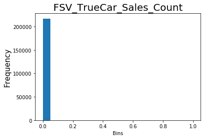

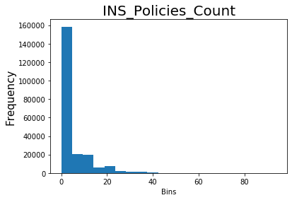

```python
features = Bobby_Data.dtypes[(Bobby_Data.dtypes==int)|(Bobby_Data.dtypes==float)].index.tolist()
for feature in features:
    hist(Bobby_Data[feature],bins=20)
    title(feature,size=20)
    ylabel('Frequency',size=15)
    xlabel('Bins')
    show()
```

# 4. Jason's Features:

```python
Jason_Features = ['Min Earliest Insurance Tx',
 'Occupation Group',
 'Marital Status',
 'Net Worth',
 'Race',
 'Member Dues Y3',
 'Member Dues Y2',
 'Member Dues Y1',
 'Birth Date',
 'ZIP5',
 'Commission',
 'Coastal ZIP9 Flag',
 'Branch Name',
 'Sort',
 'Policy Holder Flag 1',
 'State',
 'V12 Auto Count',
 'TRV Priceline Count',
 'Total Travel Records',
 'Member Count',
 'New Mover Count',
 'Member Flag',
 'Coverage Level Code']

Jason_Features = [feature.replace(' ','_') for feature in Jason_Features]

Jason_Data = NewAAAData[Jason_Features]
```

Here, it can be seen that there are some nulls that I must deal with before we all merge our data.

```python
Jason_Data.info()
```

```
<class 'pandas.core.frame.DataFrame'>
RangeIndex: 217136 entries, 0 to 217135
Data columns (total 23 columns):
 #   Column                     Non-Null Count   Dtype
---  ------                     --------------   -----
 0   Min_Earliest_Insurance_Tx  83269 non-null   object
 1   Occupation_Group           108054 non-null  object
 2   Marital_Status             111250 non-null  object
 3   Net_Worth                  115918 non-null  object
 4   Race                       126409 non-null  object
 5   Member_Dues_Y3             159870 non-null  float64
 6   Member_Dues_Y2             161469 non-null  float64
 7   Member_Dues_Y1             164114 non-null  float64
 8   Birth_Date                 203465 non-null  object
 9   ZIP5                       217073 non-null  float64
 10  Commission                 217136 non-null  object
 11  Coastal_ZIP9_Flag          217136 non-null  bool
 12  Branch_Name                217136 non-null  object
 13  Sort                       217136 non-null  int64
 14  Policy_Holder_Flag_1       217136 non-null  object
 15  State                      217136 non-null  object
 16  V12_Auto_Count             217075 non-null  float64
 17  TRV_Priceline_Count        217075 non-null  float64
 18  Total_Travel_Records       217075 non-null  float64
 19  Member_Count               217075 non-null  float64
 20  New_Mover_Count            217075 non-null  float64
 21  Member_Flag                217075 non-null  object
 22  Coverage_Level_Code        217136 non-null  object
dtypes: bool(1), float64(9), int64(1), object(12)
memory usage: 36.7+ MB
```

Since there are a few numerical fields in my set, I wanted to check the stats out for them. I did this because I needed to decide which statistical measure would be best for filling in nulls. I ultimately chose to do median for the respective fields.

```python
Jason_Data.describe(exclude=None)
```

|  | Member_Dues_Y3 | Member_Dues_Y2 | Member_Dues_Y1 | ZIP5 | Sort | V12_Auto_Count | TRV_Priceline_Count | Total_Travel_Records | Member_Count | New_Mover_Count |
| --- | --- | --- | --- | --- | --- | --- | --- | --- | --- | --- |
| count | 159870.000000 | 161469.000000 | 164114.000000 | 217073.000000 | 217136.000000 | 217075.000000 | 217075.000000 | 217075.000000 | 217075.000000 | 217075.000000 |
| mean | 63.674267 | 68.242835 | 70.370946 | 2721.783336 | 1.616231 | 0.519853 | 0.132567 | 0.223098 | 1.146797 | 0.047099 |
| std | 28.404576 | 30.477943 | 31.660821 | 6582.009308 | 0.486304 | 0.858277 | 1.035581 | 1.112309 | 0.431119 | 0.211851 |
| min | -120.900000 | -112.000000 | -171.000000 | 659.000000 | 1.000000 | 0.000000 | 0.000000 | 0.000000 | 0.000000 | 0.000000 |
| 25% | 52.000000 | 54.000000 | 54.000000 | 1803.000000 | 1.000000 | 0.000000 | 0.000000 | 0.000000 | 1.000000 | 0.000000 |
| 50% | 52.000000 | 54.000000 | 55.000000 | 2081.000000 | 2.000000 | 0.000000 | 0.000000 | 0.000000 | 1.000000 | 0.000000 |
| 75% | 82.000000 | 89.000000 | 89.000000 | 2451.000000 | 2.000000 | 1.000000 | 0.000000 | 0.000000 | 1.000000 | 0.000000 |
| max | 448.000000 | 410.600000 | 512.200000 | 99712.000000 | 2.000000 | 10.000000 | 178.000000 | 118.000000 | 9.000000 | 1.000000 |

## Member Dues

```python
Jason_Data['Member_Dues_Y1'].fillna((Jason_Data['Member_Dues_Y1'].median()), inplace=True)
Jason_Data['Member_Dues_Y2'].fillna((Jason_Data['Member_Dues_Y2'].median()), inplace=True)
Jason_Data['Member_Dues_Y3'].fillna((Jason_Data['Member_Dues_Y3'].median()), inplace=True)
```

# State

```python
Jason_Data['State'].value_counts()
```

```
MA    212069
RI       909
NH       709
CA       509
FL       364
       ...
WY         3
SD         3
ON         1
AB         1
VI         1
Name: State, Length: 55, dtype: int64
```

# Occupation Group

It can be seen here that Occupation group does not have too many bins. Around half of the records are null, so we just filled it in with "Unknown"

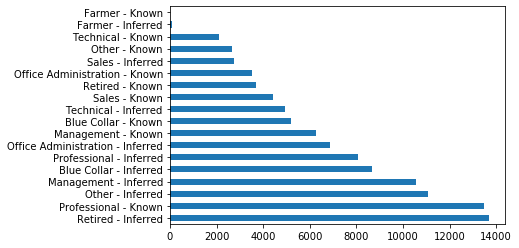

```python
display(Jason_Data['Occupation_Group'].value_counts().plot(kind='barh'))
Jason_Data["Occupation_Group"].fillna('Unknown_Occupation', inplace = True)
```

# Marital Status

There is no way to tell if someone is married or not if the value is null, so we filled the values in here with "Unknown"

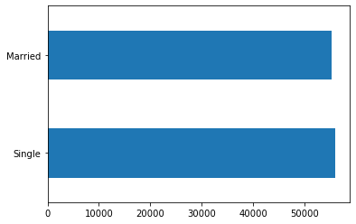

```python
display(Jason_Data['Marital_Status'].value_counts().plot(kind='barh'))
Jason_Data["Marital_Status"].fillna('Unknown', inplace = True)
```

# Net Worth

Like the previous field, we cannot tell someone's net worth based on the data. We filled it in with "Unknown", which would eventually get replaced with label encoder.

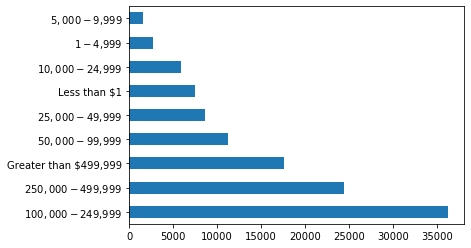

```python
Jason_Data['Net_Worth'].value_counts().plot(kind='barh')
Jason_Data["Net_Worth"].fillna('Unknown', inplace = True)
```

## Race

Fill in values with Unknown

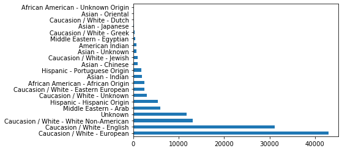

```python
Jason_Data['Race'].value_counts().plot(kind='barh')
Jason_Data["Race"].fillna('Unknown', inplace = True)
```

## Member Flag

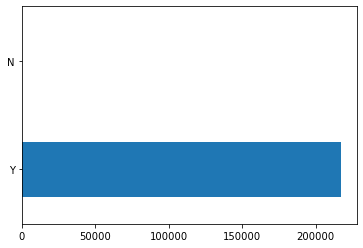

```python
Jason_Data['Member_Flag'].value_counts().plot(kind='barh')
Jason_Data = Jason_Data.drop(columns=['Member_Flag'])
```

## Coastal ZIP9 Flag

Disproportionately false, should drop

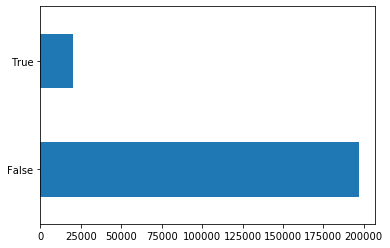

```python
Jason_Data['Coastal_ZIP9_Flag'].value_counts().plot(kind='barh')
Jason_Data = Jason_Data.drop(columns=['Coastal_ZIP9_Flag'])
```

## Branch Name

Decent distribution for most part, may still be useful

```python
Jason_Data['Branch_Name'].value_counts()
```

```
MA - BOSTON BRANCH          17931
MA - QUINCY BRANCH          14048
MA - WORCESTER BRANCH       13664
MA - SAUGUS BRANCH          13509
MA - SOUTH DENNIS BRANCH    11761
                            ...
NY - ONEONTA BRANCH             4
NH - OUT OF TERRITORY           2
NY - EAST MEADOW BRANCH         1
NJ - ROXBURY BRANCH             1
RI/MA - MILITARY                1
Name: Branch_Name, Length: 74, dtype: int64
```

## Sort

Has a decent distribution, no reason to drop currently

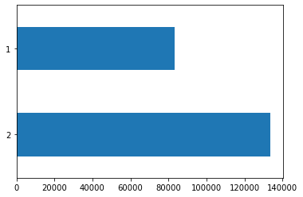

```python
Jason_Data['Sort'].value_counts().plot(kind='barh')
```

## Policy Holder Flag 1

No reason to drop, similar to distribution of last field

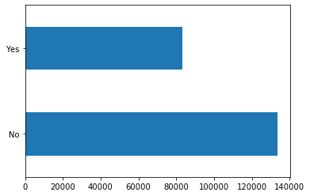

```python
Jason_Data['Policy_Holder_Flag_1'].value_counts().plot(kind='barh')
```

# V12 Auto Count

### Okay distribution although majority of data is 0. May drop later once features are cut down again

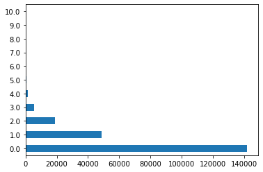

```python
Jason_Data['V12_Auto_Count'].value_counts().plot(kind='barh')
```

## Total Travel Records

Should drop, majority of data is 0 and this field is not very useful

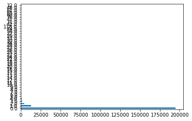

```python
Jason_Data['Total_Travel_Records'].value_counts().plot(kind='barh')
```

## Commission

Overwhelming majority is renewals, should drop for that reason

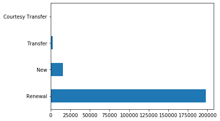

```python
Jason_Data['Commission'].value_counts().plot(kind='barh')
Jason_Data = Jason_Data.drop(columns=['Commission'])
```

## New Mover Count

Similar to last field, majority is 0 so it should be dropped

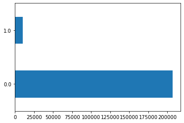

```python
Jason_Data['New_Mover_Count'].value_counts().plot(kind='barh')
Jason_Data = Jason_Data.drop(columns=['New_Mover_Count'])
```

## Zip5

```python
Jason_Data['ZIP5'].value_counts()
Jason_Data = Jason_Data.drop(columns=['ZIP5'])
```

## Age

The current age field is not good enough. There is data to fix this however. By pulling the year from the birth date field, a new and improved age field can be calculated

```python
Jason_Data['date'] = pd.to_datetime(Jason_Data['Birth_Date'])
Jason_Data['year']=Jason_Data['date'].dt.year

Jason_Data["year"].fillna(0, inplace = True)
Jason_Data['year']=Jason_Data['year'].astype(int)

Jason_Data['Age']=2020-Jason_Data['year']
Jason_Data["Age"].replace({2020: np.NaN},inplace = True)

Jason_Data['Age'].fillna((Jason_Data['Age'].median()), inplace=True)
```

## Final check for nulls

The columns with 61 missing records would be dealt with later on

```python
Jason_Data.info()
```

```
<class 'pandas.core.frame.DataFrame'>
RangeIndex: 217136 entries, 0 to 217135
Data columns (total 21 columns):
 #   Column                     Non-Null Count   Dtype
---  ------                     --------------   -----
 0   Min_Earliest_Insurance_Tx  83269 non-null   object
 1   Occupation_Group           217136 non-null  object
 2   Marital_Status             217136 non-null  object
 3   Net_Worth                  217136 non-null  object
 4   Race                       217136 non-null  object
 5   Member_Dues_Y3             217136 non-null  float64
 6   Member_Dues_Y2             217136 non-null  float64
 7   Member_Dues_Y1             217136 non-null  float64
 8   Birth_Date                 203465 non-null  object
 9   Branch_Name                217136 non-null  object
 10  Sort                       217136 non-null  int64
 11  Policy_Holder_Flag_1       217136 non-null  object
 12  State                      217136 non-null  object
 13  V12_Auto_Count             217075 non-null  float64
 14  TRV_Priceline_Count        217075 non-null  float64
 15  Total_Travel_Records       217075 non-null  float64
 16  Member_Count               217075 non-null  float64
 17  Coverage_Level_Code        217136 non-null  object
 18  date                       203465 non-null  datetime64[ns]
 19  year                       217136 non-null  int32
 20  Age                        217136 non-null  float64
dtypes: datetime64[ns](1), float64(8), int32(1), int64(1), object(10)
memory usage: 34.0+ MB
```

## Final Drops

Min Earliest Insurance Tx, Birth Date, year, and date should be dropped too, as there is no way to predict a date and there is too much of a range

```python
Jason_Data = Jason_Data.drop(columns=['Min_Earliest_Insurance_Tx','date','Birth_Date', 'year'])
```

# 5. Nathan's Features:

```python
Nate_Features = [
    'Coverage_Level_Code',
    'Coverage_Level_Parent',
    'Do_Not_Direct_Mail_Solicit',
    'Do_Not_Send_Publications',
    'Do_Not_Telemarket',
    'ERS_ENT_Count_Year_1',
    'ERS_ENT_Count_Year_2',
    'ERS_ENT_Count_Year_3',
    'ERS_Member_Cost_Year_1',
    'ERS_Member_Cost_Year_2',
    'ERS_Member_Cost_Year_3',
    'Future_Cancel_Flag',
    'Gender',
    'Join_AAA_Date',
    'Member_Expiration_Date',
    'Member_Status',
    'Member_Tenure_Years',
    'Member_Tenure_Years_Banding',
    'Member_Type', 'Membership_ID',
    'Renew_Method',
    'Policy_Holder_Flag_2',
    'Home',
    'Auto']

Nate_Data = AAAData[Nate_Features]
```

### missing data

```python
Nate_Data['Gender'].fillna(value="Member chose to not fill the information", inplace = True)
```

```python
Nate_Data['ERS_ENT_Count_Year_1'].fillna(value=0, inplace = True)
Nate_Data['ERS_ENT_Count_Year_2'].fillna(value=0, inplace = True)
```

```python
Nate_Data['ERS_Member_Cost_Year_1'].fillna(value=0, inplace = True)
Nate_Data['ERS_Member_Cost_Year_2'].fillna(value=0, inplace = True)
Nate_Data['ERS_Member_Cost_Year_3'].fillna(value=0, inplace = True)
```

### dropping data

- I am dropping “Join AAA Date” and “Membership ID” Because all these different types of dates and especially all the different IDs will not help with our model
- also dropping “Member type” because it is only one value

```python
Nate_Data = Nate_Data.drop('Join_AAA_Date',axis=1)
Nate_Data = Nate_Data.drop('Membership_ID',axis=1)
Nate_Data = Nate_Data.drop('Member_Type',axis=1)
```

```python
def value_count_dashboard(df,row_count):
    value_count_df = pd.DataFrame()

    #how can Nate_features be a global variable?
    df = Nate_Data

    categorical_features = df.dtypes[df.dtypes == object].index.tolist()
    for feature in df.dtypes[df.dtypes == object].index.tolist():
        df[feature] = df[feature].fillna('Missing Observation')
        value_count_df = pd.concat([value_count_df,pd.DataFrame([[feature,round(count/df.shape[0],3)] for feature,count in zip(df[feature].value_counts().index,df[feature].value_counts().values)],columns=[feature,f'Precentage of {feature}'])],axis=1)
    if row_count == 'MAX':
        pd.set_option('display.max_columns', None)
    else:
        pd.set_option('display.max_rows', row_count)
    pd.set_option('display.max_rows', None)
    display(value_count_df.fillna('-').T)
    pd.set_option('display.max_columns', 20)
    pd.set_option('display.max_rows', 10)
```

```python
value_count_dashboard(Nate_Features,15)
```

|  | 0 | 1 | 2 | 3 | 4 | 5 | 6 | 7 | 8 | 9 | ... | 301 | 302 | 303 | 304 | 305 | 306 | 307 | 308 | 309 | 310 |
| --- | --- | --- | --- | --- | --- | --- | --- | --- | --- | --- | --- | --- | --- | --- | --- | --- | --- | --- | --- | --- | --- |
| Coverage_Level_Code | BS | PL | PM | MC | MP | RV | - | - | - | - | ... | - | - | - | - | - | - | - | - | - | - |
| Precentage of Coverage_Level_Code | 0.557 | 0.385 | 0.049 | 0.007 | 0.001 | 0.0 | - | - | - | - | ... | - | - | - | - | - | - | - | - | - | - |
| Coverage_Level_Parent | Basic | Plus | Premier | - | - | - | - | - | - | - | ... | - | - | - | - | - | - | - | - | - | - |
| Precentage of Coverage_Level_Parent | 0.557 | 0.392 | 0.05 | - | - | - | - | - | - | - | ... | - | - | - | - | - | - | - | - | - | - |
| Future_Cancel_Flag | F | T | Missing Observation | - | - | - | - | - | - | - | ... | - | - | - | - | - | - | - | - | - | - |
| Precentage of Future_Cancel_Flag | 0.997 | 0.003 | 0.0 | - | - | - | - | - | - | - | ... | - | - | - | - | - | - | - | - | - | - |
| Gender | Member chose to not fill the information | F | M | U | - | - | - | - | - | - | ... | - | - | - | - | - | - | - | - | - | - |
| Precentage of Gender | 0.66 | 0.177 | 0.153 | 0.009 | - | - | - | - | - | - | ... | - | - | - | - | - | - | - | - | - | - |
| Member_Expiration_Date | 02/01/2022 | 07/01/2021 | 08/01/2021 | 01/01/2022 | 03/01/2022 | 04/01/2021 | 11/01/2021 | 09/01/2021 | 10/01/2021 | 02/15/2022 | ... | 10/01/2009 | 02/15/2009 | 05/15/2010 | 05/15/2022 | 12/31/2009 | 03/15/2010 | 02/01/2010 | 04/01/2010 | 04/15/2010 | 06/01/2010 |
| Precentage of Member_Expiration_Date | 0.04 | 0.039 | 0.038 | 0.034 | 0.034 | 0.033 | 0.031 | 0.031 | 0.031 | 0.031 | ... | 0.0 | 0.0 | 0.0 | 0.0 | 0.0 | 0.0 | 0.0 | 0.0 | 0.0 | 0.0 |
| Member_Status | ACTIVE | CANCELLED | PENDING | - | - | - | - | - | - | - | ... | - | - | - | - | - | - | - | - | - | - |
| Precentage of Member_Status | 0.632 | 0.257 | 0.111 | - | - | - | - | - | - | - | ... | - | - | - | - | - | - | - | - | - | - |
| Member_Tenure_Years_Banding | 4 - 6 Years | 10 - 13 Years | 7 - 9 Years | 14 - 17 Years | 2 - 3 Years | 22 - 25 Years | 18 - 21 Years | 26 - 30 Years | 1 Year or Less | 36 or More Years | ... | - | - | - | - | - | - | - | - | - | - |
| Precentage of Member_Tenure_Years_Banding | 0.148 | 0.133 | 0.113 | 0.097 | 0.097 | 0.083 | 0.082 | 0.073 | 0.066 | 0.061 | ... | - | - | - | - | - | - | - | - | - | - |
| Renew_Method | NOTICE | AUTO RENEW | PAYMENT PL | - | - | - | - | - | - | - | ... | - | - | - | - | - | - | - | - | - | - |
| Precentage of Renew_Method | 0.645 | 0.342 | 0.013 | - | - | - | - | - | - | - | ... | - | - | - | - | - | - | - | - | - | - |
| Policy_Holder_Flag_2 | No | Yes | Missing Observation | - | - | - | - | - | - | - | ... | - | - | - | - | - | - | - | - | - | - |
| Precentage of Policy_Holder_Flag_2 | 0.616 | 0.384 | 0.0 | - | - | - | - | - | - | - | ... | - | - | - | - | - | - | - | - | - | - |

18 rows × 311 columns

### drop one more column

```python
Nate_Data = Nate_Data.drop('Future_Cancel_Flag',axis=1)
```

```python
Nate_Data.head()
```

|  | Coverage_Level_Code | Coverage_Level_Parent | Do_Not_Direct_Mail_Solicit | Do_Not_Send_Publications | Do_Not_Telemarket | ERS_ENT_Count_Year_1 | ERS_ENT_Count_Year_2 | ERS_ENT_Count_Year_3 | ERS_Member_Cost_Year_1 | ERS_Member_Cost_Year_2 | ERS_Member_Cost_Year_3 | Gender | Member_Expiration_Date | Member_Status | Member_Tenure_Years | Member_Tenure_Years_Banding | Renew_Method | Policy_Holder_Flag_2 | Home | Auto |
| --- | --- | --- | --- | --- | --- | --- | --- | --- | --- | --- | --- | --- | --- | --- | --- | --- | --- | --- | --- | --- |
| 0 | BS | Basic | False | False | False | 0.0 | 0.0 | 0.0 | 0.0 | 0.0 | 0.0 | F | 12/15/2020 | PENDING | 13 | 10 - 13 Years | NOTICE | Yes | 1 | 1 |
| 1 | BS | Basic | False | False | False | 1.0 | 0.0 | 0.0 | 34.5 | 0.0 | 0.0 | Member chose to not fill the information | 02/01/2022 | ACTIVE | 24 | 22 - 25 Years | NOTICE | No | 0 | 0 |
| 2 | PM | Premier | False | False | False | 0.0 | 0.0 | 0.0 | 0.0 | 0.0 | 0.0 | Member chose to not fill the information | 11/01/2021 | ACTIVE | 35 | 31 - 35 Years | NOTICE | Yes | 1 | 1 |
| 3 | PM | Premier | False | False | False | 0.0 | 2.0 | 2.0 | 0.0 | 81.0 | 63.0 | Member chose to not fill the information | 11/01/2021 | ACTIVE | 37 | 36 or More Years | NOTICE | Yes | 0 | 0 |
| 4 | PL | Plus | False | False | False | 0.0 | 0.0 | 0.0 | 0.0 | 0.0 | 0.0 | M | 01/01/2020 | CANCELLED | 43 | 36 or More Years | NOTICE | No | 0 | 0 |

### Visualizations

```python
def Viz(df,target,drop_list):
    for feature in df.drop(drop_list,axis=1).columns:

        figure(figsize=(8,8))

        data0 = df[df[target]==0][feature].value_counts()
        data1 = df[df[target]==1][feature].value_counts()


        barh([str(feature) for feature in data0.index],log10(data0.values),label=0)
        barh([str(feature) for feature in data1.index],log10(data1.values),label=1)

        title(f"{feature}: Distinct Frequency (Log10 Scaled) vs. {target}",size=20)
        ylabel('Distinct Feature',size=15)
        xlabel('Feature Frequency (Log10 Scaled)',size=15)
        legend(title=target,title_fontsize=15,prop={"size":20})
        show()
```

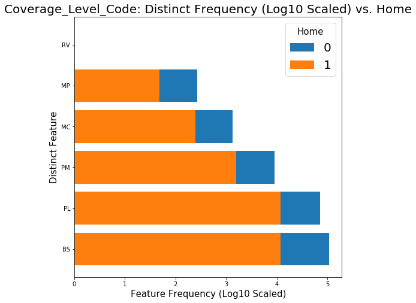

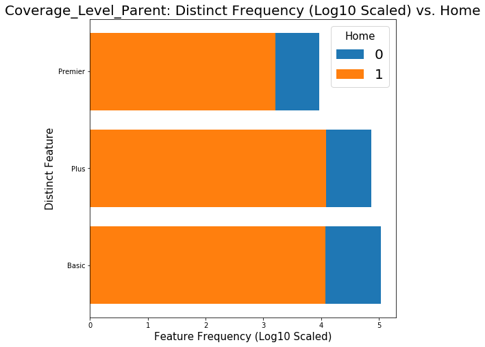

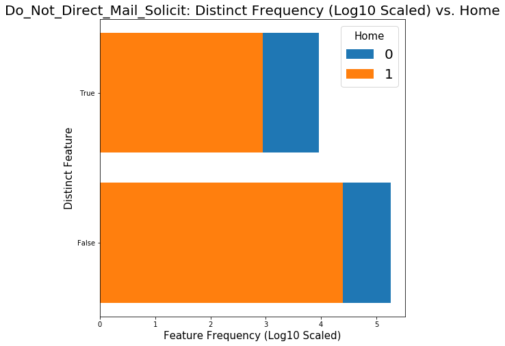

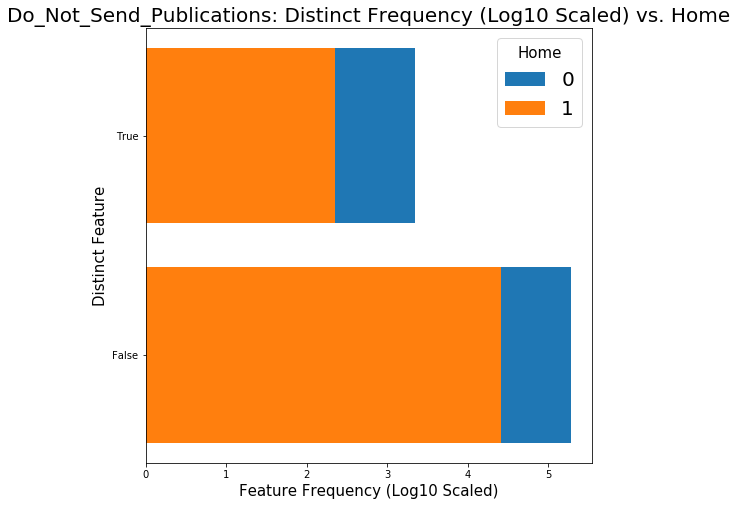

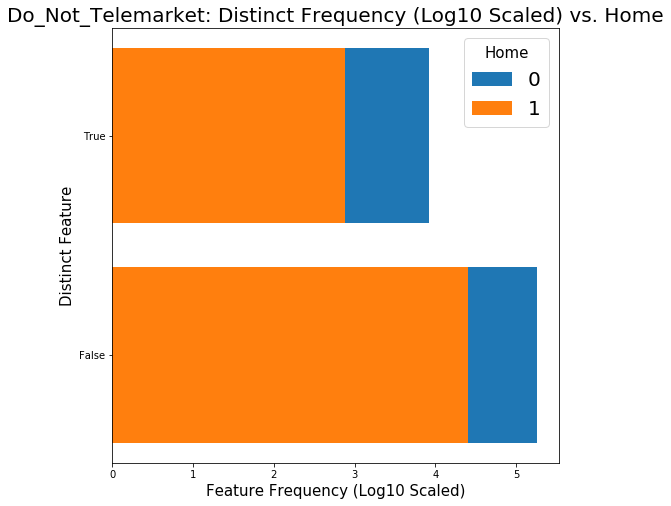

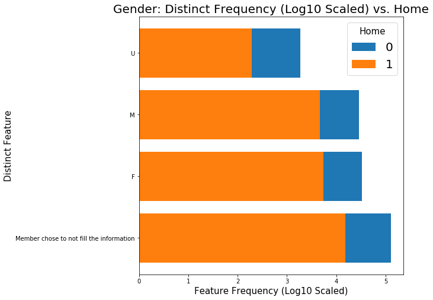

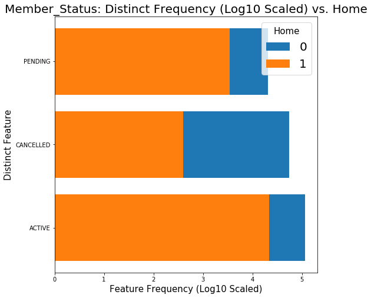

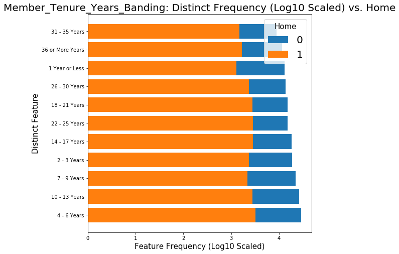

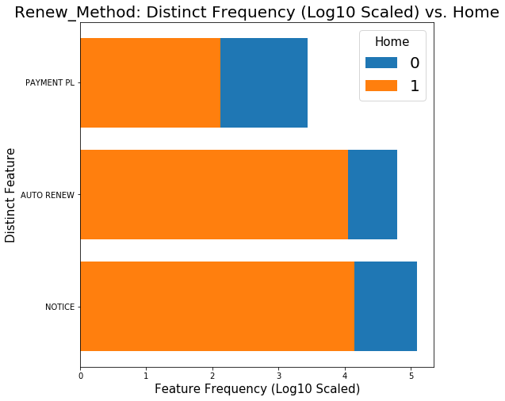

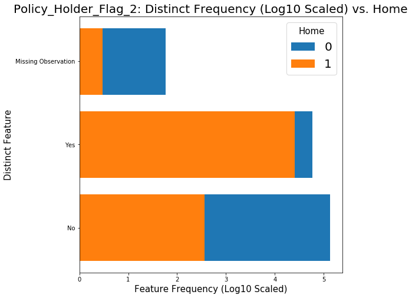

```python
Viz(Nate_Data,'Home',Nate_Data.dtypes[(Nate_Data.dtypes == float) | (Nate_Data.dtypes == int64)].index.tolist() + ['Member_Expiration_Date'])
```